# CS236781: Deep Learning on Computational Accelerators

# Homework Assignment 3

Faculty of Computer Science, Technion.

Submitted by:

| # | Name | Id | email |
| --- | --- | --- | --- |
| Student 1 | Dan Sdeor | 209509181 | dansdeor@campus.technion.ac.il |
| Student 2 | Levi Hurvitz | 313511602 | levihorvitz@campus.technion.ac.il |

## Introduction

In this assignment we'll learn to generate text with a deep multilayer RNN network based on GRU cells. Then we'll focus our attention on image generation using a variational autoencoder. We will then shift our focus to sentiment analysis: First by training a transformer-style encoder, and then by fine-tuning a pre-trained model from Hugging Face.

## General Guidelines

- Please read the [getting started page](https://vistalab-technion.github.io/cs236781/assignments/getting-started) on the course website. It explains how to **setup, run and submit** the assignment.
- This assignment requires running on GPU-enabled hardware. Please read the [course servers usage guide](https://vistalab-technion.github.io/cs236781/assignments/hpc-servers). It explains how to use and run your code on the course servers to benefit from training with GPUs.
- The text and code cells in these notebooks are intended to guide you through the assignment and help you verify your solutions. The notebooks **do not need to be edited** at all (outside of a small code block in part 4). The only exception is to fill your name(s) in the above cell before submission, and implementing a small code block in Part 4. Please do not remove sections or change the order of any cells.
- All your code (and even answers to questions) should be written in the files within the python package corresponding the assignment number (`hw1`, `hw2`, etc). You can of course use any editor or IDE to work on these files.

## Contents

- Part1: Sequence Models
  - Text generation with a char-level RNN
  - Obtaining the corpus
  - Data Preprocessing
  - Dataset Creation
  - Model Implementation
  - Generating text by sampling
  - Training
  - Generating a work of art
  - Questions
- Part 2: Variational Autoencoder:
  - Obtaining the dataset
  - The Variational Autoencoder
  - Model Implementation
  - Loss Implementation
  - Sampling
  - Training
  - Questions
- Part 3: Transformer Encoder
  - Reminder: scaled dot product attention
  - Sliding window attention
  - Multihead Sliding window attention
  - Sentiment analysis
  - Obtaining the dataset
  - Tokenizer
  - Transformer Encoder
  - Training
  - Questions
- Part 4: Fine-tuning a pretrained language model
  - Loading the dataset
  - Tokenizer
  - Loading pre-trained model
  - Fine-tuning
  - Questions

$$ \newcommand{\mat}[1]{\boldsymbol {#1}} \newcommand{\mattr}[1]{\boldsymbol {#1}^\top} \newcommand{\matinv}[1]{\boldsymbol {#1}^{-1}} \newcommand{\vec}[1]{\boldsymbol {#1}} \newcommand{\vectr}[1]{\boldsymbol {#1}^\top} \newcommand{\rvar}[1]{\mathrm {#1}} \newcommand{\rvec}[1]{\boldsymbol{\mathrm{#1}}} \newcommand{\diag}{\mathop{\mathrm {diag}}} \newcommand{\set}[1]{\mathbb {#1}} \newcommand{\norm}[1]{\left\lVert#1\right\rVert} \newcommand{\pderiv}[2]{\frac{\partial #1}{\partial #2}} \newcommand{\bb}[1]{\boldsymbol{#1}} $$

# Part 1: Sequence Models

In this part we will learn about working with text sequences using recurrent neural networks. We'll go from a raw text file all the way to a fully trained GRU-RNN model and generate works of art!

```python
import unittest
import os
import sys
import pathlib
import urllib
import shutil
import re

import numpy as np
import torch
import matplotlib.pyplot as plt

%load_ext autoreload
%autoreload 2
```

```python
test = unittest.TestCase()
plt.rcParams.update({'font.size': 12})
device = torch.device('cuda' if torch.cuda.is_available() else 'cpu')
print('Using device:', device)
```

```
Using device: cuda
```

## Text generation with a char-level RNN

### Obtaining the corpus

Let's begin by downloading a corpus containing all the works of William Shakespeare. Since he was very prolific, this corpus is fairly large and will provide us with enough data for obtaining impressive results.

```python
CORPUS_URL = 'https://github.com/cedricdeboom/character-level-rnn-datasets/raw/master/datasets/shakespeare.txt'
DATA_DIR = pathlib.Path.home().joinpath('.pytorch-datasets')

def download_corpus(out_path=DATA_DIR, url=CORPUS_URL, force=False):
    pathlib.Path(out_path).mkdir(exist_ok=True)
    out_filename = os.path.join(out_path, os.path.basename(url))

    if os.path.isfile(out_filename) and not force:
        print(f'Corpus file {out_filename} exists, skipping download.')
    else:
        print(f'Downloading {url}...')
        with urllib.request.urlopen(url) as response, open(out_filename, 'wb') as out_file:
            shutil.copyfileobj(response, out_file)
        print(f'Saved to {out_filename}.')
    return out_filename

corpus_path = download_corpus()
```

```
Corpus file /home/dansdeor/.pytorch-datasets/shakespeare.txt exists, skipping download.
```

Load the text into memory and print a snippet:

```python
with open(corpus_path, 'r', encoding='utf-8') as f:
    corpus = f.read()

print(f'Corpus length: {len(corpus)} chars')
print(corpus[7:1234])
```

```
Corpus length: 6347703 chars
ALLS WELL THAT ENDS WELL

by William Shakespeare

Dramatis Personae

  KING OF FRANCE
  THE DUKE OF FLORENCE
  BERTRAM, Count of Rousillon
  LAFEU, an old lord
  PAROLLES, a follower of Bertram
  TWO FRENCH LORDS, serving with Bertram

  STEWARD, Servant to the Countess of Rousillon
  LAVACHE, a clown and Servant to the Countess of Rousillon
  A PAGE, Servant to the Countess of Rousillon

  COUNTESS OF ROUSILLON, mother to Bertram
  HELENA, a gentlewoman protected by the Countess
  A WIDOW OF FLORENCE.
  DIANA, daughter to the Widow

  VIOLENTA, neighbour and friend to the Widow
  MARIANA, neighbour and friend to the Widow

  Lords, Officers, Soldiers, etc., French and Florentine

SCENE:
Rousillon; Paris; Florence; Marseilles

ACT I. SCENE 1.
Rousillon. The COUNT'S palace

Enter BERTRAM, the COUNTESS OF ROUSILLON, HELENA, and LAFEU, all in black

  COUNTESS. In delivering my son from me, I bury a second husband.
  BERTRAM. And I in going, madam, weep o'er my father's death anew;
    but I must attend his Majesty's command, to whom I am now in
    ward, evermore in subjection.
  LAFEU. You shall find of the King a husband, madam; you, sir, a
    father. He that so generally is at all times good must of
```

### Data Preprocessing

The first thing we'll need is to map from each unique character in the corpus to an index that will represent it in our learning process.

**TODO**: Implement the `char_maps()` function in the `hw3/charnn.py` module.

```python
import hw3.charnn as charnn

char_to_idx, idx_to_char = charnn.char_maps(corpus)
print(char_to_idx)

test.assertEqual(len(char_to_idx), len(idx_to_char))
test.assertSequenceEqual(list(char_to_idx.keys()), list(idx_to_char.values()))
test.assertSequenceEqual(list(char_to_idx.values()), list(idx_to_char.keys()))
```

```
{'\n': 0, ' ': 1, '!': 2, '"': 3, '$': 4, '&': 5, "'": 6, '(': 7, ')': 8, ',': 9, '-': 10, '.': 11, '0': 12, '1': 13, '2': 14, '3': 15, '4': 16, '5': 17, '6': 18, '7': 19, '8': 20, '9': 21, ':': 22, ';': 23, '<': 24, '?': 25, 'A': 26, 'B': 27, 'C': 28, 'D': 29, 'E': 30, 'F': 31, 'G': 32, 'H': 33, 'I…
```

Seems we have some strange characters in the corpus that are very rare and are probably due to mistakes. To reduce the length of each tensor we'll need to later represent our chars, it's best to remove them.

**TODO**: Implement the `remove_chars()` function in the `hw3/charnn.py` module.

```python
corpus, n_removed = charnn.remove_chars(corpus, ['}','$','_','<','\ufeff'])
print(f'Removed {n_removed} chars')

# After removing the chars, re-create the mappings
char_to_idx, idx_to_char = charnn.char_maps(corpus)
```

```
Removed 34 chars
```

The next thing we need is an **embedding** of the chracters. An embedding is a representation of each token from the sequence as a tensor. For a char-level RNN, our tokens will be chars and we can thus use the simplest possible embedding: encode each char as a **one-hot** tensor. In other words, each char will be represented as a tensor whos length is the total number of unique chars (`V`) which contains all zeros except at the index corresponding to that specific char.

**TODO**: Implement the functions `chars_to_onehot()` and `onehot_to_chars()` in the `hw3/charnn.py` module.

```python
# Wrap the actual embedding functions for calling convenience
def embed(text):
    return charnn.chars_to_onehot(text, char_to_idx)

def unembed(embedding):
    return charnn.onehot_to_chars(embedding, idx_to_char)

text_snippet = corpus[3104:3148]
print(text_snippet)
print(embed(text_snippet[0:3]))

test.assertEqual(text_snippet, unembed(embed(text_snippet)))
test.assertEqual(embed(text_snippet).dtype, torch.int8)
```

```
brine a maiden can season her praise in.

tensor([[0, 0, 0, 0, 0, 0, 0, 0, 0, 0, 0, 0, 0, 0, 0, 0, 0, 0, 0, 0, 0, 0, 0, 0,
         0, 0, 0, 0, 0, 0, 0, 0, 0, 0, 0, 0, 0, 0, 0, 0, 0, 0, 0, 0, 0, 0, 0, 0,
         0, 0, 0, 0, 0, 1, 0, 0, 0, 0, 0, 0, 0, 0, 0, 0, 0, 0, 0, 0, 0, 0, 0, 0,
         0, 0, 0, 0, 0, 0],
        [0, 0, 0, 0, 0, 0, 0, 0, 0, 0, 0, 0, 0, 0, 0, 0, 0, 0, 0, 0, 0, 0, 0, 0,
         0, 0, 0, 0, 0, 0, 0, 0, 0, 0, 0, 0, 0, 0, 0, 0, 0, 0, 0, 0, 0, 0, 0, 0,
         0, 0, 0, 0, 0, 0, 0, 0, 0, 0, 0, 0, 0, 0, 0, 0, 0, 0, 0, 0, 0, 1, 0, 0,
         0, 0, 0, 0, 0, 0],
        [0, 0, 0, 0, 0, 0, 0, 0, 0, 0, 0, 0, 0, 0, 0, 0, 0, 0, 0, 0, 0, 0, 0, 0,
         0, 0, 0, 0, 0, 0, 0, 0, 0, 0, 0, 0, 0, 0, 0, 0, 0, 0, 0, 0, 0, 0, 0, 0,
         0, 0, 0, 0, 0, 0, 0, 0, 0, 0, 0, 0, 1, 0, 0, 0, 0, 0, 0, 0, 0, 0, 0, 0,
         0, 0, 0, 0, 0, 0]], dtype=torch.int8)
```

### Dataset Creation

We wish to train our model to generate text by constantly predicting what the next char should be based on the past. To that end we'll need to train our recurrent network in a way similar to a classification task. At each timestep, we input a char and set the expected output (label) to be the next char in the original sequence.

We will split our corpus into shorter sequences of length `S` chars (see question below). Each **sample** we provide our model with will therefore be a tensor of shape `(S,V)` where `V` is the embedding dimension. Our model will operate sequentially on each char in the sequence. For each sample, we'll also need a **label**. This is simply another sequence, shifted by one char so that the label of each char is the next char in the corpus.

**TODO**: Implement the `chars_to_labelled_samples()` function in the `hw3/charnn.py` module.

```python
# Create dataset of sequences
seq_len = 64
vocab_len = len(char_to_idx)

# Create labelled samples
samples, labels = charnn.chars_to_labelled_samples(corpus, char_to_idx, seq_len, device)
print(f'samples shape: {samples.shape}')
print(f'labels shape: {labels.shape}')

# Test shapes
num_samples = (len(corpus) - 1) // seq_len
test.assertEqual(samples.shape, (num_samples, seq_len, vocab_len))
test.assertEqual(labels.shape, (num_samples, seq_len))

# Test content
for _ in range(1000):
    # random sample
    i = np.random.randint(num_samples, size=(1,))[0]
    # Compare to corpus
    test.assertEqual(unembed(samples[i]), corpus[i*seq_len:(i+1)*seq_len], msg=f"content mismatch in sample {i}")
    # Compare to labels
    sample_text = unembed(samples[i])
    label_text = str.join('', [idx_to_char[j.item()] for j in labels[i]])
    test.assertEqual(sample_text[1:], label_text[0:-1], msg=f"label mismatch in sample {i}")
```

```
samples shape: torch.Size([99182, 64, 78])
labels shape: torch.Size([99182, 64])
```

Let's print a few consecutive samples. You should see that the text continues between them.

```python
import re
import random

i = random.randrange(num_samples-5)
for i in range(i, i+5):
    test.assertEqual(len(samples[i]), seq_len)
    s = re.sub(r'\s+', ' ', unembed(samples[i])).strip()
    print(f'sample [{i}]:\n\t{s}')
```

```
sample [91419]:
	hem then, or else hold close thy lips. KING HENRY VI: I prithee
sample [91420]:
	, give no limits to my tongue: I am a king, and privileged to sp
sample [91421]:
	eak. CLIFFORD: My liege, the wound that bred this meeting here
sample [91422]:
	Cannot be cured by words; therefore be still. RICHARD: Then, ex
sample [91423]:
	ecutioner, unsheathe thy sword: By him that made us all, I am re
```

As usual, instead of feeding one sample at a time into our model's forward we'll work with **batches** of samples. This means that at every timestep, our model will operate on a batch of chars that are from **different sequences**. Effectively this will allow us to parallelize training our model by dong matrix-matrix multiplications instead of matrix-vector during the forward pass.

An important nuance is that we need the batches to be **contiguous**, i.e. sample $k$ in batch $j$ should continue sample $k$ from batch $j-1$. The following figure illustrates this:

[figure not shown]

If we naïvely take consecutive samples into batches, e.g. `[0,1,...,B-1]`, `[B,B+1,...,2B-1]` and so on, we won't have contiguous sequences at the same index between adjacent batches.

To accomplish this we need to tell our `DataLoader` which samples to combine together into one batch. We do this by implementing a custom PyTorch `Sampler`, and providing it to our `DataLoader`.

**TODO**: Implement the `SequenceBatchSampler` class in the `hw3/charnn.py` module.

```python
from hw3.charnn import SequenceBatchSampler

sampler = SequenceBatchSampler(dataset=range(32), batch_size=10)
sampler_idx = list(sampler)
print('sampler_idx =\n', sampler_idx)

# Test the Sampler
test.assertEqual(len(sampler_idx), 30)
batch_idx = np.array(sampler_idx).reshape(-1, 10)
for k in range(10):
    test.assertEqual(np.diff(batch_idx[:, k], n=2).item(), 0)
```

```
sampler_idx =
 [tensor(0), tensor(3), tensor(6), tensor(9), tensor(12), tensor(15), tensor(18), tensor(21), tensor(24), tensor(27), tensor(1), tensor(4), tensor(7), tensor(10), tensor(13), tensor(16), tensor(19), tensor(22), tensor(25), tensor(28), tensor(2), tensor(5), tensor(8), tensor(11), tensor(14), tensor(1…
```

Even though we're working with sequences, we can still use the standard PyTorch `Dataset`/`DataLoader` combo. For the dataset we can use a built-in class, `TensorDataset` to return tuples of `(sample, label)` from the `samples` and `labels` tensors we created above. The `DataLoader` will be provided with our custom `Sampler` so that it generates appropriate batches.

```python
import torch.utils.data

# Create DataLoader returning batches of samples.
batch_size = 32

ds_corpus = torch.utils.data.TensorDataset(samples, labels)
sampler_corpus = SequenceBatchSampler(ds_corpus, batch_size)
dl_corpus = torch.utils.data.DataLoader(ds_corpus, batch_size=batch_size, sampler=sampler_corpus, shuffle=False)
```

Let's see what that gives us:

```python
print(f'num batches: {len(dl_corpus)}')

x0, y0 = next(iter(dl_corpus))
print(f'shape of a batch of samples: {x0.shape}')
print(f'shape of a batch of labels: {y0.shape}')
```

```
num batches: 3100
shape of a batch of samples: torch.Size([32, 64, 78])
shape of a batch of labels: torch.Size([32, 64])
```

Now lets look at the same sample index from multiple batches taken from our corpus.

```python
# Check that sentences in in same index of different batches complete each other.
k = random.randrange(batch_size)
for j, (X, y) in enumerate(dl_corpus,):
    print(f'=== batch {j}, sample {k} ({X[k].shape}): ===')
    s = re.sub(r'\s+', ' ', unembed(X[k])).strip()
    print(f'\t{s}')
    if j==4: break
```

```
=== batch 0, sample 18 (torch.Size([64, 78])): ===
	nstrous. Iago, who began't? MONTANO. If partially affined, or
=== batch 1, sample 18 (torch.Size([64, 78])): ===
	leagued in office, Thou dost deliver more or less than truth
=== batch 2, sample 18 (torch.Size([64, 78])): ===
	, Thou art no soldier. IAGO. Touch me not
=== batch 3, sample 18 (torch.Size([64, 78])): ===
	so near: I had rather have this tongue cut from my mouth
=== batch 4, sample 18 (torch.Size([64, 78])): ===
	Than it should do offense to Michael Cassio; Yet, I pers
```

### Model Implementation

Finally, our data set is ready so we can focus on our model.

We'll implement here is a multilayer gated recurrent unit (GRU) model, with dropout. This model is a type of RNN which performs similar to the well-known LSTM model, but it's somewhat easier to train because it has less parameters. We'll modify the regular GRU slightly by applying dropout to the hidden states passed between layers of the model.

The model accepts an input $\mat{X}\in\set{R}^{S\times V}$ containing a sequence of embedded chars. It returns an output $\mat{Y}\in\set{R}^{S\times V}$ of predictions for the next char and the final hidden state $\mat{H}\in\set{R}^{L\times H}$. Here $S$ is the sequence length, $V$ is the vocabulary size (number of unique chars), $L$ is the number of layers in the model and $H$ is the hidden dimension.

Mathematically, the model's forward function at layer $k\in[1,L]$ and timestep $t\in[1,S]$ can be described as

$$ \begin{align} \vec{z_t}^{[k]} &= \sigma\left(\vec{x}^{[k]}_t {\mattr{W}_{\mathrm{xz}}}^{[k]} + \vec{h}_{t-1}^{[k]} {\mattr{W}_{\mathrm{hz}}}^{[k]} + \vec{b}_{\mathrm{z}}^{[k]}\right) \\ \vec{r_t}^{[k]} &= \sigma\left(\vec{x}^{[k]}_t {\mattr{W}_{\mathrm{xr}}}^{[k]} + \vec{h}_{t-1}^{[k]} {\mattr{W}_{\mathrm{hr}}}^{[k]} + \vec{b}_{\mathrm{r}}^{[k]}\right) \\ \vec{g_t}^{[k]} &= \tanh\left(\vec{x}^{[k]}_t {\mattr{W}_{\mathrm{xg}}}^{[k]} + (\vec{r_t}^{[k]}\odot\vec{h}_{t-1}^{[k]}) {\mattr{W}_{\mathrm{hg}}}^{[k]} + \vec{b}_{\mathrm{g}}^{[k]}\right) \\ \vec{h_t}^{[k]} &= \vec{z}^{[k]}_t \odot \vec{h}^{[k]}_{t-1} + \left(1-\vec{z}^{[k]}_t\right)\odot \vec{g_t}^{[k]} \end{align} $$

The input to each layer is, $$ \mat{X}^{[k]} = \begin{bmatrix} {\vec{x}_1}^{[k]} \\ \vdots \\ {\vec{x}_S}^{[k]} \end{bmatrix} = \begin{cases} \mat{X} & \mathrm{if} ~k = 1~ \\ \mathrm{dropout}_p \left( \begin{bmatrix} {\vec{h}_1}^{[k-1]} \\ \vdots \\ {\vec{h}_S}^{[k-1]} \end{bmatrix} \right) & \mathrm{if} ~1 < k \leq L+1~ \end{cases}. $$

The output of the entire model is then, $$ \mat{Y} = \mat{X}^{[L+1]} {\mattr{W}_{\mathrm{hy}}} + \mat{B}_{\mathrm{y}} $$

and the final hidden state is $$ \mat{H} = \begin{bmatrix} {\vec{h}_S}^{[1]} \\ \vdots \\ {\vec{h}_S}^{[L]} \end{bmatrix}. $$

Notes:

- $t\in[1,S]$ is the timestep, i.e. the current position within the sequence of each sample.
- $\vec{x}_t^{[k]}$ is the input of layer $k$ at timestep $t$, respectively.
- The outputs of the **last layer** $\vec{y}_t^{[L]}$, are the predicted next characters for every input char. These are similar to class scores in classification tasks.
- The hidden states at the **last timestep**, $\vec{h}_S^{[k]}$, are the final hidden state returned from the model.
- $\sigma(\cdot)$ is the sigmoid function, i.e. $\sigma(\vec{z}) = 1/(1+e^{-\vec{z}})$ which returns values in $(0,1)$.
- $\tanh(\cdot)$ is the hyperbolic tangent, i.e. $\tanh(\vec{z}) = (e^{2\vec{z}}-1)/(e^{2\vec{z}}+1)$ which returns values in $(-1,1)$.
- $\vec{h_t}^{[k]}$ is the hidden state of layer $k$ at time $t$. This can be thought of as the memory of that layer.
- $\vec{g_t}^{[k]}$ is the candidate hidden state for time $t+1$.
- $\vec{z_t}^{[k]}$ is known as the update gate. It combines the previous state with the input to determine how much the current state will be combined with the new candidate state. For example, if $\vec{z_t}^{[k]}=\vec{1}$ then the current input has no effect on the output.
- $\vec{r_t}^{[k]}$ is known as the reset gate. It combines the previous state with the input to determine how much of the previous state will affect the current state candidate. For example if $\vec{r_t}^{[k]}=\vec{0}$ the previous state has no effect on the current candidate state.

Here's a graphical representation of the GRU's forward pass at each timestep. The $\vec{\tilde{h}}$ in the image is our $\vec{g}$ (candidate next state).

[figure not shown]

You can see how the reset and update gates allow the model to completely ignore it's previous state, completely ignore it's input, or any mixture of those states (since the gates are actually continuous and between $(0,1)$).

Here's a graphical representation of the entire model. You can ignore the $c_t^{[k]}$ (cell state) variables (which are relevant for LSTM models). Our model has only the hidden state, $h_t^{[k]}$. Also notice that we added dropout between layers (i.e., on the up arrows).

[figure not shown]

The purple tensors are inputs (a sequence and initial hidden state per layer), and the green tensors are outputs (another sequence and final hidden state per layer). Each blue block implements the above forward equations. Blocks that are on the same vertical level are at the same layer, and therefore share parameters.

**TODO**: Implement the `MultilayerGRU` class in the `hw3/charnn.py` module.

Notes:

- You'll need to handle input **batches** now. The math is identical to the above, but all the tensors will have an extra batch dimension as their first dimension.
- Use the diagram above to help guide your implementation. It will help you visualize what shapes to returns where, etc.

```python
in_dim = vocab_len
h_dim = 256
n_layers = 3
model = charnn.MultilayerGRU(in_dim, h_dim, out_dim=in_dim, n_layers=n_layers)
model = model.to(device)
print(model)

# Test forward pass
y, h = model(x0.to(dtype=torch.float, device=device))
print(f'y.shape={y.shape}')
print(f'h.shape={h.shape}')

test.assertEqual(y.shape, (batch_size, seq_len, vocab_len))
test.assertEqual(h.shape, (batch_size, n_layers, h_dim))
test.assertEqual(len(list(model.parameters())), 9 * n_layers + 2)
```

```
MultilayerGRU(
  (dropout): Dropout(p=0, inplace=False)
  (sigmoid): Sigmoid()
  (tanh): Tanh()
  (hz_layer0): Linear(in_features=256, out_features=256, bias=True)
  (hr_layer0): Linear(in_features=256, out_features=256, bias=True)
  (hg_layer0): Linear(in_features=256, out_features=256, bias=True)
  (xz_layer0): Linear(in_features=78, out_features=256, bias=False)
  (xr_layer0): Linear(in_features=78, out_features=256, bias=False)
  (xg_layer0): Linear(in_features=78, out_features=256, bias=False)
  (hz_layer1): Linear(in_features=256, out_features=256, bias=True)
  (hr_layer1): Linear(in_features=256, out_features=256, bias=True)
  (hg_layer1): Linear(in_features=256, out_features=256, bias=True)
  (xz_layer1): Linear(in_features=256, out_features=256, bias=False)
  (xr_layer1): Linear(in_features=256, out_features=256, bias=False)
  (xg_layer1): Linear(in_features=256, out_features=256, bias=False)
  (hz_layer2): Linear(in_features=256, out_features=256, bias=True)
  (hr_layer2): Linear(in_features=256, out_features=256, bias=True)
  (hg_layer2): Linear(in_features=256, out_features=256, bias=True)
  (xz_layer2): Linear(in_features=256, out_features=256, bias=False)
  (xr_layer2): Linear(in_features=256, out_features=256, bias=False)
  (xg_layer2): Linear(in_features=256, out_features=256, bias=False)
  (hy): Linear(in_features=256, out_features=78, bias=True)
)
y.shape=torch.Size([32, 64, 78])
h.shape=torch.Size([32, 3, 256])
```

### Generating text by sampling

Now that we have a model, we can implement **text generation** based on it. The idea is simple: At each timestep our model receives one char $x_t$ from the input sequence and outputs scores $y_t$ for what the next char should be. We'll convert these scores into a probability over each of the possible chars. In other words, for each input char $x_t$ we create a probability distribution for the next char conditioned on the current one and the state of the model (representing all previous inputs): $$p(x_{t+1}|x_t, \vec{h}_t).$$

Once we have such a distribution, we'll sample a char from it. This will be the first char of our generated sequence. Now we can feed this new char into the model, create another distribution, sample the next char and so on. Note that it's crucial to propagate the hidden state when sampling.

The important point however is how to create the distribution from the scores. One way, as we saw in previous ML tasks, is to use the softmax function. However, a drawback of softmax is that it can generate very diffuse (more uniform) distributions if the score values are very similar. When sampling, we would prefer to control the distributions and make them less uniform to increase the chance of sampling the char(s) with the highest scores compared to the others.

To control the variance of the distribution, a common trick is to add a hyperparameter $T$, known as the *temperature* to the softmax function. The class scores are simply scaled by $T$ before softmax is applied: $$ \mathrm{softmax}_T(\vec{y}) = \frac{e^{\vec{y}/T}}{\sum_k e^{y_k/T}} $$

A low $T$ will result in less uniform distributions and vice-versa.

**TODO**: Implement the `hot_softmax()` function in the `hw3/charnn.py` module.

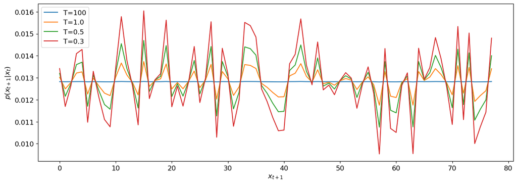

```python
scores = y[0,0,:].detach()
_, ax = plt.subplots(figsize=(15,5))

for t in reversed([0.3, 0.5, 1.0, 100]):
    ax.plot(charnn.hot_softmax(scores, temperature=t).cpu().numpy(), label=f'T={t}')
ax.set_xlabel('$x_{t+1}$')
ax.set_ylabel('$p(x_{t+1}|x_t)$')
ax.legend()

uniform_proba = 1/len(char_to_idx)
uniform_diff = torch.abs(charnn.hot_softmax(scores, temperature=100) - uniform_proba)
test.assertTrue(torch.all(uniform_diff < 1e-4))
```

**TODO**: Implement the `generate_from_model()` function in the `hw3/charnn.py` module.

```python
for _ in range(3):
    text = charnn.generate_from_model(model, "foobar", 50, (char_to_idx, idx_to_char), T=0.5)
    print(text)
    test.assertEqual(len(text), 50)
```

```
foobar"J"g'c
1?)vWeAaQC&1:(eLeWrvSe0[f,7PRW2GlC)"4
foobarAf,vR7m!e96dXL]Vg):Zq4Z]]kv7Qgv.kVMj"j;v'l&R
foobarpDuRI1qJ-eU
!qdlBs5UyuuFv0-9)s:AnC0TJHmaER3S
```

### Training

To train this model, we'll calculate the loss at each time step by comparing the predicted char to the actual char from our label. We can use cross entropy since per char it's similar to a classification problem. We'll then sum the losses over the sequence and back-propagate the gradients though time. Notice that the back-propagation algorithm will "visit" each layer's parameter tensors multiple times, so we'll accumulate gradients in parameters of the blocks. Luckily `autograd` will handle this part for us.

As usual, the first step of training will be to try and **overfit** a large model (many parameters) to a tiny dataset. Again, this is to ensure the model and training code are implemented correctly, i.e. that the model can learn.

For a generative model such as this, overfitting is slightly trickier than for classification. What we'll aim to do is to get our model to **memorize** a specific sequence of chars, so that when given the first char in the sequence it will immediately spit out the rest of the sequence verbatim.

Let's create a tiny dataset to memorize.

```python
# Pick a tiny subset of the dataset
subset_start, subset_end = 1001, 1005
ds_corpus_ss = torch.utils.data.Subset(ds_corpus, range(subset_start, subset_end))
batch_size_ss = 1
sampler_ss = SequenceBatchSampler(ds_corpus_ss, batch_size=batch_size_ss)
dl_corpus_ss = torch.utils.data.DataLoader(ds_corpus_ss, batch_size_ss, sampler=sampler_ss, shuffle=False)

# Convert subset to text
subset_text = ''
for i in range(subset_end - subset_start):
    subset_text += unembed(ds_corpus_ss[i][0])
print(f'Text to "memorize":\n\n{subset_text}')
```

```
Text to "memorize":

TRAM. What would you have?
  HELENA. Something; and scarce so much; nothing, indeed.
    I would not tell you what I would, my lord.
    Faith, yes:
    Strangers and foes do sunder and not kiss.
  BERTRAM. I pray you, stay not, but in haste to horse.
  HE
```

Now let's implement the first part of our training code.

**TODO**: Implement the `train_epoch()` and `train_batch()` methods of the `RNNTrainer` class in the `hw3/training.py` module. You must think about how to correctly handle the hidden state of the model between batches and epochs for this specific task (i.e. text generation).

```python
import torch.nn as nn
import torch.optim as optim
from hw3.training import RNNTrainer

torch.manual_seed(42)

lr = 0.01
num_epochs = 500

in_dim = vocab_len
h_dim = 128
n_layers = 2
loss_fn = nn.CrossEntropyLoss()
model = charnn.MultilayerGRU(in_dim, h_dim, out_dim=in_dim, n_layers=n_layers).to(device)
optimizer = optim.Adam(model.parameters(), lr=lr)
trainer = RNNTrainer(model, loss_fn, optimizer, device)

for epoch in range(num_epochs):
    epoch_result = trainer.train_epoch(dl_corpus_ss, verbose=False)

    # Every X epochs, we'll generate a sequence starting from the first char in the first sequence
    # to visualize how/if/what the model is learning.
    if epoch == 0 or (epoch+1) % 25 == 0:
        avg_loss = np.mean(epoch_result.losses)
        accuracy = np.mean(epoch_result.accuracy)
        print(f'\nEpoch #{epoch+1}: Avg. loss = {avg_loss:.3f}, Accuracy = {accuracy:.2f}%')

        generated_sequence = charnn.generate_from_model(model, subset_text[0],
                                                        seq_len*(subset_end-subset_start),
                                                        (char_to_idx,idx_to_char), T=0.1)

        # Stop if we've successfully memorized the small dataset.
        print(generated_sequence)
        if generated_sequence == subset_text:
            break

# Test successful overfitting
test.assertGreater(epoch_result.accuracy, 99)
test.assertEqual(generated_sequence, subset_text)
```

```
Epoch #1: Avg. loss = 3.836, Accuracy = 18.36%
Twn     t a t tt tt      t  t  tt tt     ttttttt tntt tt t  t  t tt    t    tt t tt  t tt  ttttttt     t   tt  t     tttttt    t  t tt ttttttttt    t  ttt   ttt t t   ttttt  t ttttt   t tttt ttt  t     tt  t    tt   ttt  t ttt t   ttttt t t   tt tt tt tt

Epoch #25: Avg. loss = 0.021, Accuracy = 100.00%
TRAM. What would you have?
  HELENA. Something; and scarce so much; nothing, indeed.
    I would not tell you what I would, my lord.
    Faith, yes:
    Strangers and foes do sunder and not kiss.
  BERTRAM. I pray you, stay not, but in haste to horse.
  HE
```

OK, so training works - we can memorize a short sequence. We'll now train a much larger model on our large dataset. You'll need a GPU for this part.

First, lets set up our dataset and models for training. We'll split our corpus into 90% train and 10% test-set. Also, we'll use a learning-rate scheduler to control the learning rate during training.

**TODO**: Set the hyperparameters in the `part1_rnn_hyperparams()` function of the `hw3/answers.py` module.

```python
from hw3.answers import part1_rnn_hyperparams

hp = part1_rnn_hyperparams()
print('hyperparams:\n', hp)

### Dataset definition
vocab_len = len(char_to_idx)
batch_size = hp['batch_size']
seq_len = hp['seq_len']
train_test_ratio = 0.9
num_samples = (len(corpus) - 1) // seq_len
num_train = int(train_test_ratio * num_samples)

samples, labels = charnn.chars_to_labelled_samples(corpus, char_to_idx, seq_len, device)

ds_train = torch.utils.data.TensorDataset(samples[:num_train], labels[:num_train])
sampler_train = SequenceBatchSampler(ds_train, batch_size)
dl_train = torch.utils.data.DataLoader(ds_train, batch_size, shuffle=False, sampler=sampler_train, drop_last=True)

ds_test = torch.utils.data.TensorDataset(samples[num_train:], labels[num_train:])
sampler_test = SequenceBatchSampler(ds_test, batch_size)
dl_test = torch.utils.data.DataLoader(ds_test, batch_size, shuffle=False, sampler=sampler_test, drop_last=True)

print(f'Train: {len(dl_train):3d} batches, {len(dl_train)*batch_size*seq_len:7d} chars')
print(f'Test:  {len(dl_test):3d} batches, {len(dl_test)*batch_size*seq_len:7d} chars')

### Training definition
in_dim = out_dim = vocab_len
checkpoint_file = 'checkpoints/rnn'
num_epochs = 50
early_stopping = 5

model = charnn.MultilayerGRU(in_dim, hp['h_dim'], out_dim, hp['n_layers'], hp['dropout'])
loss_fn = nn.CrossEntropyLoss()
optimizer = optim.Adam(model.parameters(), lr=hp['learn_rate'])
scheduler = optim.lr_scheduler.ReduceLROnPlateau(
    optimizer, mode='max', factor=hp['lr_sched_factor'], patience=hp['lr_sched_patience'], verbose=True
)
trainer = RNNTrainer(model, loss_fn, optimizer, device)
```

```
hyperparams:
 {'batch_size': 512, 'seq_len': 80, 'h_dim': 128, 'n_layers': 3, 'dropout': 0.2, 'learn_rate': 0.002, 'lr_sched_factor': 0.1, 'lr_sched_patience': 3}
Train: 139 batches, 5693440 chars
Test:   15 batches,  614400 chars
```

The code blocks below will train the model and save checkpoints containing the training state and the best model parameters to a file. This allows you to stop training and resume it later from where you left.

Note that you can use the `main.py` script provided within the assignment folder to run this notebook from the command line as if it were a python script by using the `run-nb` subcommand. This allows you to train your model using this notebook without starting jupyter. You can combine this with `srun` or `sbatch` to run the notebook with a GPU on the course servers.

**TODO**:

- Implement the `fit()` method of the `Trainer` class. You can reuse the relevant implementation parts from HW2, but make sure to implement early stopping and checkpoints.
- Implement the `test_epoch()` and `test_batch()` methods of the `RNNTrainer` class in the `hw3/training.py` module.
- Run the following block to train.
- When training is done and you're satisfied with the model's outputs, rename the checkpoint file to `checkpoints/rnn_final.pt`. This will cause the block to skip training and instead load your saved model when running the homework submission script. Note that your submission zip file will not include the checkpoint file. This is OK.

```
ACT I.:'
nWnt(7AEvK,F"?w91BuQ]!Z(JCFz
ah8l[MQh6jRGrp]IziRGRCs]
o'ACkBgbOnJnE5ZvwAToJ.t:vluWl,Zis)rap
*** Loading checkpoint file checkpoints/rnn.pt
--- EPOCH 1/50 ---
train_batch (Avg. Loss 1.351, Accuracy 59.2): 100%|██████████████████████████████████████████████████████████████████████████████| 139/139 [00:51<00:00,  2.71it/s]
test_batch (Avg. Loss 1.413, Accuracy 55.7): 100%|█████████████████████████████████████████████████████████████████████████████████| 15/15 [00:01<00:00,  8.32it/s]
*** Saved checkpoint checkpoints/rnn.pt at epoch 1
ACT I.

                                              Enter SERVANT

    See it would do the short m
--- EPOCH 2/50 ---
train_batch (Avg. Loss 1.348, Accuracy 59.3): 100%|██████████████████████████████████████████████████████████████████████████████| 139/139 [01:10<00:00,  1.97it/s]
test_batch (Avg. Loss 1.411, Accuracy 55.8): 100%|█████████████████████████████████████████████████████████████████████████████████| 15/15 [00:02<00:00,  5.50it/s]
*** Saved checkpoint checkpoints/rnn.pt at epoch 2
ACT I.

                                                 Enter ALINO


--- EPOCH 3/50 ---
train_batch (Avg. Loss 1.347, Accuracy 59.3): 100%|██████████████████████████████████████████████████████████████████████████████| 139/139 [02:18<00:00,  1.01it/s]
test_batch (Avg. Loss 1.410, Accuracy 55.7): 100%|█████████████████████████████████████████████████████████████████████████████████| 15/15 [00:04<00:00,  3.47it/s]
*** Saved checkpoint checkpoints/rnn.pt at epoch 3
ACT I.

                                            Enter SIR ANGELO, SOLDIER and the TroilUS

    H
--- EPOCH 4/50 ---
train_batch (Avg. Loss 1.346, Accuracy 59.3): 100%|██████████████████████████████████████████████████████████████████████████████| 139/139 [02:31<00:00,  1.09s/it]
test_batch (Avg. Loss 1.409, Accuracy 55.8): 100%|█████████████████████████████████████████████████████████████████████████████████| 15/15 [00:06<00:00,  2.43it/s]
*** Saved checkpoint checkpoints/rnn.pt at epoch 4
ACT I.

                                                         Exit SERVANT
  PROTEUS. How been th
```

[output cut: 280 more lines]

```

  Ham. He shall deserve thee come to the worl
--- EPOCH 37/50 ---
train_batch (Avg. Loss 1.318, Accuracy 60.0): 100%|██████████████████████████████████████████████████████████████████████████████| 139/139 [00:51<00:00,  2.70it/s]
test_batch (Avg. Loss 1.391, Accuracy 56.2): 100%|█████████████████████████████████████████████████████████████████████████████████| 15/15 [00:01<00:00,  7.86it/s]
*** Saved checkpoint checkpoints/rnn.pt at epoch 37
ACT I.

                                      Enter BEROWNE, and ANTONY

  LADY MACBETH. Here comes
--- EPOCH 38/50 ---
train_batch (Avg. Loss 1.318, Accuracy 60.0): 100%|██████████████████████████████████████████████████████████████████████████████| 139/139 [00:51<00:00,  2.69it/s]
test_batch (Avg. Loss 1.391, Accuracy 56.2): 100%|█████████████████████████████████████████████████████████████████████████████████| 15/15 [00:01<00:00,  8.25it/s]
early stopping
```

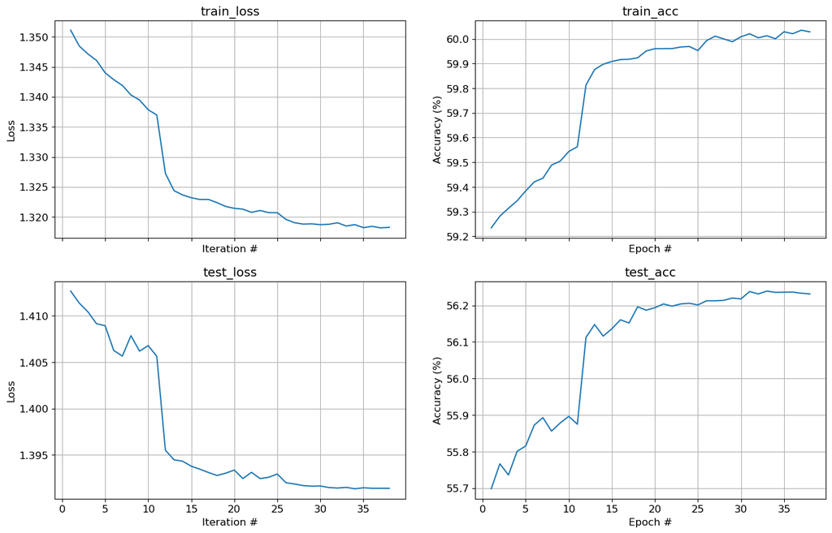

```python
from cs236781.plot import plot_fit

def post_epoch_fn(epoch, train_res, test_res, verbose):
    # Update learning rate
    scheduler.step(test_res.accuracy)
    # Sample from model to show progress
    if verbose:
        start_seq = "ACT I."
        generated_sequence = charnn.generate_from_model(
            model, start_seq, 100, (char_to_idx,idx_to_char), T=0.5
        )
        print(generated_sequence)

# Train, unless final checkpoint is found
checkpoint_file_final = f'{checkpoint_file}_final.pt'
if os.path.isfile(checkpoint_file_final):
    print(f'*** Loading final checkpoint file {checkpoint_file_final} instead of training')
    saved_state = torch.load(checkpoint_file_final, map_location=device)
    model.load_state_dict(saved_state['model_state'])
else:
    try:
        # Print pre-training sampling
        print(charnn.generate_from_model(model, "ACT I.", 100, (char_to_idx,idx_to_char), T=0.5))

        fit_res = trainer.fit(dl_train, dl_test, num_epochs, max_batches=None,
                              post_epoch_fn=post_epoch_fn, early_stopping=early_stopping,
                              checkpoints=checkpoint_file, print_every=1)

        fig, axes = plot_fit(fit_res)
    except KeyboardInterrupt as e:
        print('\n *** Training interrupted by user')
```

### Generating a work of art

Armed with our fully trained model, let's generate the next Hamlet! You should experiment with modifying the sampling temperature and see what happens.

The text you generate should “look” like a Shakespeare play: old-style English words and sentence structure, directions for the actors (like “Exit/Enter”), sections (Act I/Scene III) etc. There will be no coherent plot of course, but it should at least seem like a Shakespearean play when not looking too closely. If this is not what you see, go back, debug and/or and re-train.

**TODO**: Specify the generation parameters in the `part1_generation_params()` function within the `hw3/answers.py` module.

```python
from hw3.answers import part1_generation_params

start_seq, temperature = part1_generation_params()

generated_sequence = charnn.generate_from_model(
    model, start_seq, 10000, (char_to_idx,idx_to_char), T=temperature
)

print(generated_sequence)
```

```
A thousand the court of the King
                                                                                                                                                                                                         Exeunt

SCENE III.
A strange officer

Enter the KING and the DUKE OF SYRACUSE, and SERVANT

  CASSIUS. I will not see thee to the King of the street
    That I shall be so much and see the state.
    The street of the street of the streets of the strange.
    The street of the street of the streets of the strange.
    The street of the strange thing the streets of the strange,
    And the streets of the streets of the streets,
    And the streets of the streets of the streets,
    And the streets of the streets of the streets,
    And the streets of the streets of the streets,
    And the streets of the streets of the streets,
    And the streets of the streets of the streets,
    And the streets of the streets of the streets,
    And the streets of the streets of the streets,
    And the streets of the streets of the streets,
    And the streets of the streets of the streets,
    And the streets of the streets of the streets,
    And the streets of the streets of the streets,
    And the streets of the streets of the streets,
    And the streets of the streets of the streets,
    And the streets of the streets of the streets,
    And the streets of the streets of the streets,
    And the streets of the streets of the streets,
    And the streets of the streets of the streets,
    And the streets of the streets of the streets,
    And the streets of the streets of the streets,
    And the streets of the streets of the streets,
    And the streets of the streets of the streets,
    And the streets of the streets of the streets,
    And the streets of the streets of the streets,
    And the streets of the streets of the streets,
    And the streets of the streets of the streets,
    And the streets of the streets of the streets,
```

[output cut: 142 more lines]

```
    And the streets of the streets of the streets,
    And the streets of the streets of the streets,
    And the streets of the streets of the streets,
    And the streets of the streets of the streets,
    And the streets of the streets of the streets,
    And the streets of the streets of the streets,
    And the streets of the streets of the streets,
    And the streets of the streets of the streets,
    And the streets of the streets of the streets,
    And the streets of the streets of the streets,
    And the streets of the streets of the streets,
    And the streets of the streets of the streets,
    And the streets of the streets of the streets,
    And the streets of the streets of the streets,
    And the streets of the streets of the streets,
```

## Questions

**TODO** Answer the following questions. Write your answers in the appropriate variables in the module `hw3/answers.py`.

```python
from cs236781.answers import display_answer
import hw3.answers
```

### Question 1

Why do we split the corpus into sequences instead of training on the whole text?

```python
display_answer(hw3.answers.part1_q1)
```

1. Training on the whole text, especially for large texts, can present a few challenges in the machine learning and particularly deep learning. Here are some reasons why we split the corpus into sequences:

• Memory Constraints: In most modern deep learning architectures, the entire sequence needs to be loaded into memory at once for processing. If we use the whole text, the sequence can become so long that it exceeds the memory capacity of the hardware (such as GPU memory), especially for large datasets.

• Batch Processing: By splitting the text into smaller sequences, we can process multiple sequences in parallel, which greatly speeds up training.

• Learning Context: By breaking the text into smaller sequences, the model can learn from the local context around words and gradually understand the overall semantics of the text.

• Backpropagation Through Time (BPTT): For large sequences, BPTT can become computationally expensive and more prone to errors due to the vanishing and exploding gradient problems.

### Question 2

How is it possible that the generated text clearly shows memory longer than the sequence length?

```python
display_answer(hw3.answers.part1_q2)
```

4. Model architecture's memory mechanisms: Certain types of sequence models, like LSTMs and Transformers, are designed with mechanisms to 'remember' or give importance to critical information from earlier in the sequence. For example, LSTMs have a cell state that carries forward relevant information through time, while Transformers use an attention mechanism to focus on important parts of the input sequence. These mechanisms provide the models with an effective 'memory' that spans beyond the immediate input sequence length.

### Question 3

Why are we not shuffling the order of batches when training?

```python
display_answer(hw3.answers.part1_q3)
```

3. When dealing with sequential data, such as time series or textual data, we typically avoid shuffling the order of the batches during the training process. This practice is primarily due to the inherent nature of sequence models like RNN, LSTM, or Transformers, which are designed to leverage the order of data points for effective learning.

Shuffling the data could disrupt the temporal relationships that these models strive to learn. For instance, in a text sequence, the contextual meaning of a word often heavily relies on the preceding words. Shuffling the data would reorganize the word order, thereby rendering the model incapable of learning these crucial dependencies.

### Question 4

1. Why do we lower the temperature for sampling (compared to the default of $1.0$)?
2. What happens when the temperature is very high and why?
3. What happens when the temperature is very low and why?

```python
display_answer(hw3.answers.part1_q4)
```

4. The 'temperature' in the context of a neural network, such as an RNN used for text generation, is a parameter that controls the randomness of the predictions.

• High Temperature: If the temperature is high (e.g., much greater than 1.0), it makes the probability distribution closer to uniform. This means all characters (or whatever the output space is) have almost equal probability of being the next output. The output becomes more randomized and less predictable. This can result in more diverse and creative output, but it also tends to produce more mistakes and less coherent sequences.

• Low Temperature: If the temperature is low (e.g., much less than 1.0), it makes the probability distribution sharper, increasing the likelihood of the most probable output. This tends to make the model more confident in its predictions but also more conservative. It will likely choose the most likely next character, resulting in more predictable and coherent output, but potentially less diverse and creative.

• Temperature of 1.0: This is often the default and provides a balance between diversity/creativity and accuracy/predictability.

we lower the temperature for sampling to make the generated text more coherent and less random. While this might make the output less diverse and potentially less creative, it increases the chances of the output making sense and being grammatically correct. The ideal temperature often requires some experimentation and can depend on the specific task and the trained model.

$$ \newcommand{\mat}[1]{\boldsymbol {#1}} \newcommand{\mattr}[1]{\boldsymbol {#1}^\top} \newcommand{\matinv}[1]{\boldsymbol {#1}^{-1}} \newcommand{\vec}[1]{\boldsymbol {#1}} \newcommand{\vectr}[1]{\boldsymbol {#1}^\top} \newcommand{\rvar}[1]{\mathrm {#1}} \newcommand{\rvec}[1]{\boldsymbol{\mathrm{#1}}} \newcommand{\diag}{\mathop{\mathrm {diag}}} \newcommand{\set}[1]{\mathbb {#1}} \newcommand{\norm}[1]{\left\lVert#1\right\rVert} \newcommand{\pderiv}[2]{\frac{\partial #1}{\partial #2}} \newcommand{\bm}[1]{{\bf #1}} \newcommand{\bb}[1]{\bm{\mathrm{#1}}} $$

# Part 2: Variational Autoencoder

In this part we will learn to generate new data using a special type of autoencoder model which allows us to sample from its latent space. We'll implement and train a VAE and use it to generate new images.

```python
import unittest
import os
import sys
import pathlib
import urllib
import shutil
import re
import zipfile

import numpy as np
import torch
import matplotlib.pyplot as plt

%load_ext autoreload
%autoreload 2
```

```
The autoreload extension is already loaded. To reload it, use:
  %reload_ext autoreload
```

```python
test = unittest.TestCase()
plt.rcParams.update({'font.size': 12})
device = torch.device('cuda' if torch.cuda.is_available() else 'cpu')
print('Using device:', device)
```

```
Using device: cuda
```

### Obtaining the dataset

Let's begin by downloading a dataset of images that we want to learn to generate. We'll use the [Labeled Faces in the Wild](http://vis-www.cs.umass.edu/lfw/) (LFW) dataset which contains many labeled faces of famous individuals.

We're going to train our generative model to generate a specific face, not just any face. Since the person with the most images in this dataset is former president George W. Bush, we'll set out to train a Bush Generator :)

However, if you feel adventurous and/or prefer to generate something else, feel free to edit the `PART2_CUSTOM_DATA_URL` variable in `hw3/answers.py`.

```python
import cs236781.plot as plot
import cs236781.download
from hw3.answers import PART2_CUSTOM_DATA_URL as CUSTOM_DATA_URL

DATA_DIR = pathlib.Path.home().joinpath('.pytorch-datasets')
if CUSTOM_DATA_URL is None:
    DATA_URL = 'http://vis-www.cs.umass.edu/lfw/lfw-bush.zip'
else:
    DATA_URL = CUSTOM_DATA_URL

_, dataset_dir = cs236781.download.download_data(out_path=DATA_DIR, url=DATA_URL, extract=True, force=False)
```

```
File C:\Users\Dan\.pytorch-datasets\lfw-bush.zip exists, skipping download.
Extracting C:\Users\Dan\.pytorch-datasets\lfw-bush.zip...
Extracted 531 to C:\Users\Dan\.pytorch-datasets\lfw/George_W_Bush
```

Create a `Dataset` object that will load the extraced images:

```python
import torchvision.transforms as T
from torchvision.datasets import ImageFolder

im_size = 64
tf = T.Compose([
    # Resize to constant spatial dimensions
    T.Resize((im_size, im_size)),
    # PIL.Image -> torch.Tensor
    T.ToTensor(),
    # Dynamic range [0,1] -> [-1, 1]
    T.Normalize(mean=(.5,.5,.5), std=(.5,.5,.5)),
])

ds_gwb = ImageFolder(os.path.dirname(dataset_dir), tf)
```

OK, let's see what we got. You can run the following block multiple times to display a random subset of images from the dataset.

```
Found 530 images in dataset folder.
```

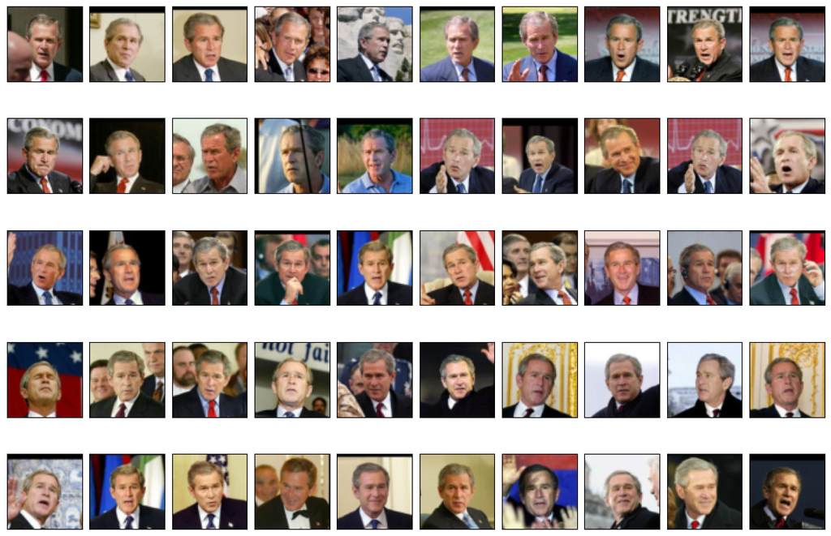

```python
_ = plot.dataset_first_n(ds_gwb, 50, figsize=(15,10), nrows=5)
print(f'Found {len(ds_gwb)} images in dataset folder.')
```

```python
x0, y0 = ds_gwb[0]
x0 = x0.unsqueeze(0).to(device)
print(x0.shape)

test.assertSequenceEqual(x0.shape, (1, 3, im_size, im_size))
```

```
torch.Size([1, 3, 64, 64])
```

## The Variational Autoencoder

An autoencoder is a model which learns a representation of data in an **unsupervised** fashion (i.e without any labels). Recall it's general form from the lecture:

[figure not shown]

An autoencoder maps an instance $\bb{x}$ to a **latent-space** representation $\bb{z}$. It has an encoder part, $\Phi_{\bb{\alpha}}(\bb{x})$ (a model with parameters $\bb{\alpha}$) and a decoder part, $\Psi_{\bb{\beta}}(\bb{z})$ (a model with parameters $\bb{\beta}$).

While autoencoders can learn useful representations, generally it's hard to use them as generative models because there's no distribution we can sample from in the latent space. In other words, we have no way to choose a point $\bb{z}$ in the latent space such that $\Psi(\bb{z})$ will end up on the data manifold in the instance space.

[figure not shown]

The variational autoencoder (VAE), first proposed by [Kingma and Welling](https://arxiv.org/pdf/1312.6114.pdf), addresses this issue by taking a probabilistic perspective. Briefly, a VAE model can be described as follows.

We define, in Baysean terminology,

- The **prior** distribution $p(\bb{Z})$ on points in the latent space.
- The **posterior** distribution of points in the latent spaces given a specific instance: $p(\bb{Z}|\bb{X})$.
- The **likelihood** distribution of a sample $\bb{X}$ given a latent-space representation: $p(\bb{X}|\bb{Z})$.
- The **evidence** distribution $p(\bb{X})$ which is the distribution of the instance space due to the generative process.

To create our variational **decoder** we'll further specify:

- A parametric likelihood distribution, $p _{\bb{\beta}}(\bb{X} | \bb{Z}=\bb{z}) = \mathcal{N}( \Psi _{\bb{\beta}}(\bb{z}) , \sigma^2 \bb{I} )$. The interpretation is that given a latent $\bb{z}$, we map it to a point normally distributed around the point calculated by our decoder neural network. Note that here $\sigma^2$ is a hyperparameter while $\vec{\beta}$ represents the network parameters.
- A fixed latent-space prior distribution of $p(\bb{Z}) = \mathcal{N}(\bb{0},\bb{I})$.

This setting allows us to generate a new instance $\bb{x}$ by sampling $\bb{z}$ from the multivariate normal distribution, obtaining the instance-space mean $\Psi _{\bb{\beta}}(\bb{z})$ using our decoder network, and then sampling $\bb{x}$ from $\mathcal{N}( \Psi _{\bb{\beta}}(\bb{z}) , \sigma^2 \bb{I} )$.

Our variational **encoder** will approximate the posterior with a parametric distribution $q _{\bb{\alpha}}(\bb{Z} | \bb{x}) = \mathcal{N}( \bb{\mu} _{\bb{\alpha}}(\bb{x}), \mathrm{diag}\{ \bb{\sigma}^2_{\bb{\alpha}}(\bb{x}) \} )$. The interpretation is that our encoder model, $\Phi_{\vec{\alpha}}(\bb{x})$, calculates the mean and variance of the posterior distribution, and samples $\bb{z}$ based on them. An important nuance here is that our network can't contain any stochastic elements that depend on the model parameters, otherwise we won't be able to back-propagate to those parameters. So sampling $\bb{z}$ from $\mathcal{N}( \bb{\mu} _{\bb{\alpha}}(\bb{x}), \mathrm{diag}\{ \bb{\sigma}^2_{\bb{\alpha}}(\bb{x}) \} )$ is not an option. The solution is to use what's known as the **reparametrization trick**: sample from an isotropic Gaussian, i.e. $\bb{u}\sim\mathcal{N}(\bb{0},\bb{I})$ (which doesn't depend on trainable parameters), and calculate the latent representation as $\bb{z} = \bb{\mu} _{\bb{\alpha}}(\bb{x}) + \bb{u}\odot\bb{\sigma}_{\bb{\alpha}}(\bb{x})$.

To train a VAE model, we maximize the evidence distribution, $p(\bb{X})$ (see question below). The **VAE loss** can therefore be stated as minimizing $\mathcal{L} = -\mathbb{E}_{\bb{x}} \log p(\bb{X})$. Although this expectation is intractable, we can obtain a lower-bound for $p(\bb{X})$ (the evidence lower bound, "ELBO", shown in the lecture):

$$ \log p(\bb{X}) \ge \mathbb{E} _{\bb{z} \sim q _{\bb{\alpha}} }\left[ \log p _{\bb{\beta}}(\bb{X} | \bb{z}) \right] - \mathcal{D} _{\mathrm{KL}}\left(q _{\bb{\alpha}}(\bb{Z} | \bb{X})\,\left\|\, p(\bb{Z} )\right.\right) $$

where $ \mathcal{D} _{\mathrm{KL}}(q\left\|\right.p) = \mathbb{E}_{\bb{z}\sim q}\left[ \log \frac{q(\bb{Z})}{p(\bb{Z})} \right] $ is the Kullback-Liebler divergence, which can be interpreted as the information gained by using the posterior $q(\bb{Z|X})$ instead of the prior distribution $p(\bb{Z})$.

By remembering that the likelihood is a Gaussian distribution with a diagonal covariance and by applying the reparametrization trick, we can write the above as

$$ \mathcal{L}(\vec{\alpha},\vec{\beta}) = \mathbb{E} _{\bb{x}} \left[ \mathbb{E} _{\bb{z} \sim q _{\bb{\alpha}} } \left[ \frac{1}{2\sigma^2}\left\| \bb{x}- \Psi _{\bb{\beta}}\left( \bb{\mu} _{\bb{\alpha}}(\bb{x}) + \bb{\Sigma}^{\frac{1}{2}} _{\bb{\alpha}}(\bb{x}) \bb{u} \right) \right\| _2^2 \right] + \mathcal{D} _{\mathrm{KL}}\left(q _{\bb{\alpha}}(\bb{Z} | \bb{x})\,\left\|\, p(\bb{Z} )\right.\right) \right]. $$

### Model Implementation

Obviously our model will have two parts, an encoder and a decoder. Since we're working with images, we'll implement both as deep **convolutional** networks, where the decoder is a "mirror image" of the encoder implemented with adjoint (AKA transposed) convolutions. Between the encoder CNN and the decoder CNN we'll implement the sampling from the parametric posterior approximator $q_{\bb{\alpha}}(\bb{Z}|\bb{x})$ to make it a VAE model and not just a regular autoencoder (of course, this is not yet enough to create a VAE, since we also need a special loss function which we'll get to later).

First let's implement just the CNN part of the Encoder network (this is not the full $\Phi_{\vec{\alpha}}(\bb{x})$ yet). As usual, it should take an input image and map to a activation volume of a specified depth. We'll consider this volume as the features we extract from the input image. Later we'll use these to create the latent space representation of the input.

**TODO**: Implement the `EncoderCNN` class in the `hw3/autoencoder.py` module. Implement any CNN architecture you like. If you need "architecture inspiration" you can see e.g. [this](https://arxiv.org/pdf/1512.09300.pdf) or [this](https://arxiv.org/pdf/1511.06434.pdf) paper.

```python
import hw3.autoencoder as autoencoder

in_channels = 3
out_channels = 1024
encoder_cnn = autoencoder.EncoderCNN(in_channels, out_channels).to(device)
print(encoder_cnn)

h = encoder_cnn(x0)
print(h.shape)

test.assertEqual(h.dim(), 4)
test.assertSequenceEqual(h.shape[0:2], (1, out_channels))
```

```
EncoderCNN(
  (cnn): Sequential(
    (0): Conv2d(3, 32, kernel_size=(5, 5), stride=(1, 1))
    (1): BatchNorm2d(32, eps=1e-05, momentum=0.1, affine=True, track_running_stats=True)
    (2): ReLU()
    (3): Conv2d(32, 64, kernel_size=(5, 5), stride=(1, 1))
    (4): BatchNorm2d(64, eps=1e-05, momentum=0.1, affine=True, track_running_stats=True)
    (5): ReLU()
    (6): Conv2d(64, 128, kernel_size=(5, 5), stride=(1, 1))
    (7): BatchNorm2d(128, eps=1e-05, momentum=0.1, affine=True, track_running_stats=True)
    (8): ReLU()
    (9): Conv2d(128, 1024, kernel_size=(5, 5), stride=(1, 1))
    (10): BatchNorm2d(1024, eps=1e-05, momentum=0.1, affine=True, track_running_stats=True)
    (11): ReLU()
  )
)
torch.Size([1, 1024, 48, 48])
```

Now let's implement the CNN part of the Decoder. Again this is not yet the full $\Psi _{\bb{\beta}}(\bb{z})$. It should take an activation volume produced by your `EncoderCNN` and output an image of the same dimensions as the Encoder's input was. This can be a CNN which is like a "mirror image" of the the Encoder. For example, replace convolutions with transposed convolutions, downsampling with up-sampling etc. Consult the documentation of [ConvTranspose2D](https://pytorch.org/docs/0.4.1/nn.html#convtranspose2d) to figure out how to reverse your convolutional layers in terms of input and output dimensions. Note that the decoder doesn't have to be exactly the opposite of the encoder and you can experiment with using a different architecture.

**TODO**: Implement the `DecoderCNN` class in the `hw3/autoencoder.py` module.

```python
decoder_cnn = autoencoder.DecoderCNN(in_channels=out_channels, out_channels=in_channels).to(device)
print(decoder_cnn)
x0r = decoder_cnn(h)
print(x0r.shape)

test.assertEqual(x0.shape, x0r.shape)

# Should look like colored noise
T.functional.to_pil_image(x0r[0].cpu().detach())
```

```
DecoderCNN(
  (cnn): Sequential(
    (0): ConvTranspose2d(1024, 128, kernel_size=(5, 5), stride=(1, 1))
    (1): BatchNorm2d(128, eps=1e-05, momentum=0.1, affine=True, track_running_stats=True)
    (2): ReLU()
    (3): ConvTranspose2d(128, 64, kernel_size=(5, 5), stride=(1, 1))
    (4): BatchNorm2d(64, eps=1e-05, momentum=0.1, affine=True, track_running_stats=True)
    (5): ReLU()
    (6): ConvTranspose2d(64, 32, kernel_size=(5, 5), stride=(1, 1))
    (7): BatchNorm2d(32, eps=1e-05, momentum=0.1, affine=True, track_running_stats=True)
    (8): ReLU()
    (9): ConvTranspose2d(32, 3, kernel_size=(5, 5), stride=(1, 1))
    (10): BatchNorm2d(3, eps=1e-05, momentum=0.1, affine=True, track_running_stats=True)
    (11): ReLU()
  )
)
torch.Size([1, 3, 64, 64])
```

Let's now implement the full VAE Encoder, $\Phi_{\vec{\alpha}}(\vec{x})$. It will work as follows:

1. Produce a feature vector $\vec{h}$ from the input image $\vec{x}$.
2. Use two affine transforms to convert the features into the mean and log-variance of the posterior, i.e. $$ \begin{align} \bb{\mu} _{\bb{\alpha}}(\bb{x}) &= \vec{h}\mattr{W}_{\mathrm{h\mu}} + \vec{b}_{\mathrm{h\mu}} \\ \log\left(\bb{\sigma}^2_{\bb{\alpha}}(\bb{x})\right) &= \vec{h}\mattr{W}_{\mathrm{h\sigma^2}} + \vec{b}_{\mathrm{h\sigma^2}} \end{align} $$
3. Use the **reparametrization trick** to create the latent representation $\vec{z}$.

Notice that we model the **log** of the variance, not the actual variance. The above formulation is proposed in appendix C of the [VAE paper](https://arxiv.org/pdf/1312.6114.pdf).

**TODO**: Implement the `encode()` method in the `VAE` class within the `hw3/autoencoder.py` module. You'll also need to define your parameters in `__init__()`.

```python
z_dim = 2
vae = autoencoder.VAE(encoder_cnn, decoder_cnn, x0[0].size(), z_dim).to(device)
print(vae)

z, mu, log_sigma2 = vae.encode(x0)

test.assertSequenceEqual(z.shape, (1, z_dim))
test.assertTrue(z.shape == mu.shape == log_sigma2.shape)

print(f'mu(x0)={list(*mu.detach().cpu().numpy())}, sigma2(x0)={list(*torch.exp(log_sigma2).detach().cpu().numpy())}')
```

```
VAE(
  (features_encoder): EncoderCNN(
    (cnn): Sequential(
      (0): Conv2d(3, 32, kernel_size=(5, 5), stride=(1, 1))
      (1): BatchNorm2d(32, eps=1e-05, momentum=0.1, affine=True, track_running_stats=True)
      (2): ReLU()
      (3): Conv2d(32, 64, kernel_size=(5, 5), stride=(1, 1))
      (4): BatchNorm2d(64, eps=1e-05, momentum=0.1, affine=True, track_running_stats=True)
      (5): ReLU()
      (6): Conv2d(64, 128, kernel_size=(5, 5), stride=(1, 1))
      (7): BatchNorm2d(128, eps=1e-05, momentum=0.1, affine=True, track_running_stats=True)
      (8): ReLU()
      (9): Conv2d(128, 1024, kernel_size=(5, 5), stride=(1, 1))
      (10): BatchNorm2d(1024, eps=1e-05, momentum=0.1, affine=True, track_running_stats=True)
      (11): ReLU()
    )
  )
  (features_decoder): DecoderCNN(
    (cnn): Sequential(
      (0): ConvTranspose2d(1024, 128, kernel_size=(5, 5), stride=(1, 1))
      (1): BatchNorm2d(128, eps=1e-05, momentum=0.1, affine=True, track_running_stats=True)
      (2): ReLU()
      (3): ConvTranspose2d(128, 64, kernel_size=(5, 5), stride=(1, 1))
      (4): BatchNorm2d(64, eps=1e-05, momentum=0.1, affine=True, track_running_stats=True)
      (5): ReLU()
      (6): ConvTranspose2d(64, 32, kernel_size=(5, 5), stride=(1, 1))
      (7): BatchNorm2d(32, eps=1e-05, momentum=0.1, affine=True, track_running_stats=True)
      (8): ReLU()
      (9): ConvTranspose2d(32, 3, kernel_size=(5, 5), stride=(1, 1))
      (10): BatchNorm2d(3, eps=1e-05, momentum=0.1, affine=True, track_running_stats=True)
      (11): ReLU()
    )
  )
  (calc_mean): Linear(in_features=2359296, out_features=2, bias=True)
  (calc_log_var): Linear(in_features=2359296, out_features=2, bias=True)
  (reverse_transformation): Linear(in_features=2, out_features=2359296, bias=True)
)
mu(x0)=[0.30361924, -0.4502339], sigma2(x0)=[1.0236297, 0.8112893]
```

Let's sample some 2d latent representations for an input image `x0` and visualize them.

```
sampled mu tensor([ 0.4028, -0.4567])
sampled sigma2 tensor([1.0094, 0.8009])
```

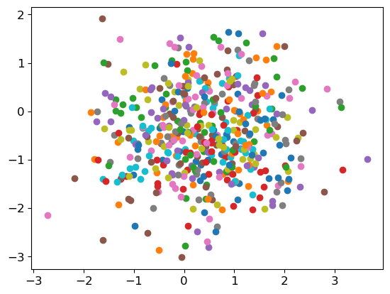

```python
# Sample from q(Z|x)
N = 500
Z = torch.zeros(N, z_dim)
_, ax = plt.subplots()
with torch.no_grad():
    for i in range(N):
        Z[i], _, _ = vae.encode(x0)
        ax.scatter(*Z[i].cpu().numpy())

# Should be close to the mu/sigma in the previous block above
print('sampled mu', torch.mean(Z, dim=0))
print('sampled sigma2', torch.var(Z, dim=0))
```

Let's now implement the full VAE Decoder, $\Psi _{\bb{\beta}}(\bb{z})$. It will work as follows:

1. Produce a feature vector $\tilde{\vec{h}}$ from the latent vector $\vec{z}$ using an affine transform.
2. Reconstruct an image $\tilde{\vec{x}}$ from $\tilde{\vec{h}}$ using the decoder CNN.

**TODO**: Implement the `decode()` method in the `VAE` class within the `hw3/autoencoder.py` module. You'll also need to define your parameters in `__init__()`. You may need to also re-run the block above after you implement this.

```python
x0r = vae.decode(z)

test.assertSequenceEqual(x0r.shape, x0.shape)
```

Our model's `forward()` function will simply return `decode(encode(x))` as well as the calculated mean and log-variance of the posterior.

```python
x0r, mu, log_sigma2 = vae(x0)

test.assertSequenceEqual(x0r.shape, x0.shape)
test.assertSequenceEqual(mu.shape, (1, z_dim))
test.assertSequenceEqual(log_sigma2.shape, (1, z_dim))
T.functional.to_pil_image(x0r[0].detach().cpu())
```

[output not shown]

### Loss Implementation

In practice, since we're using SGD, we'll drop the expectation over $\bb{X}$ and instead sample an instance from the training set and compute a point-wise loss. Similarly, we'll drop the expectation over $\bb{Z}$ by sampling from $q_{\vec{\alpha}}(\bb{Z}|\bb{x})$. Additionally, because the KL divergence is between two Gaussian distributions, there is a closed-form expression for it. These points bring us to the following point-wise loss:

$$ \ell(\vec{\alpha},\vec{\beta};\bb{x}) = \frac{1}{\sigma^2 d_x} \left\| \bb{x}- \Psi _{\bb{\beta}}\left( \bb{\mu} _{\bb{\alpha}}(\bb{x}) + \bb{\Sigma}^{\frac{1}{2}} _{\bb{\alpha}}(\bb{x}) \bb{u} \right) \right\| _2^2 + \mathrm{tr}\,\bb{\Sigma} _{\bb{\alpha}}(\bb{x}) + \|\bb{\mu} _{\bb{\alpha}}(\bb{x})\|^2 _2 - d_z - \log\det \bb{\Sigma} _{\bb{\alpha}}(\bb{x}), $$

where $d_z$ is the dimension of the latent space, $d_x$ is the dimension of the input and $\bb{u}\sim\mathcal{N}(\bb{0},\bb{I})$. This pointwise loss is the quantity that we'll compute and minimize with gradient descent. The first term corresponds to the data-reconstruction loss, while the second term corresponds to the KL-divergence loss. Note that the scaling by $d_x$ is not derived from the original loss formula and was added directly to the pointwise loss just to normalize the data term.

**TODO**: Implement the `vae_loss()` function in the `hw3/autoencoder.py` module.

```python
from hw3.autoencoder import vae_loss
torch.manual_seed(42)

def test_vae_loss():
    # Test data
    N, C, H, W = 10, 3, 64, 64
    z_dim = 32
    x  = torch.randn(N, C, H, W)*2 - 1
    xr = torch.randn(N, C, H, W)*2 - 1
    z_mu = torch.randn(N, z_dim)
    z_log_sigma2 = torch.randn(N, z_dim)
    x_sigma2 = 0.9

    loss, _, _ = vae_loss(x, xr, z_mu, z_log_sigma2, x_sigma2)

    test.assertAlmostEqual(loss.item(), 58.3234367, delta=1e-3)
    return loss

test_vae_loss()
```

```
tensor(58.3234)
```

### Sampling

The main advantage of a VAE is that it can by used as a generative model by sampling the latent space, since we optimize for a isotropic Gaussian prior $p(\bb{Z})$ in the loss function. Let's now implement this so that we can visualize how our model is doing when we train.

**TODO**: Implement the `sample()` method in the `VAE` class within the `hw3/autoencoder.py` module.

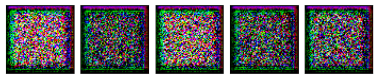

```python
samples = vae.sample(5)
_ = plot.tensors_as_images(samples)
```

### Training

Time to train!

**TODO**:

1. Implement the `VAETrainer` class in the `hw3/training.py` module. Make sure to implement the `checkpoints` feature of the `Trainer` class if you haven't done so already in Part 1.
2. Tweak the hyperparameters in the `part2_vae_hyperparams()` function within the `hw3/answers.py` module.

```python
import torch.optim as optim
from torch.utils.data import random_split
from torch.utils.data import DataLoader
from torch.nn import DataParallel
from hw3.training import VAETrainer
from hw3.answers import part2_vae_hyperparams

torch.manual_seed(42)

# Hyperparams
hp = part2_vae_hyperparams()
batch_size = hp['batch_size']
h_dim = hp['h_dim']
z_dim = hp['z_dim']
x_sigma2 = hp['x_sigma2']
learn_rate = hp['learn_rate']
betas = hp['betas']

# Data
split_lengths = [int(len(ds_gwb)*0.9), int(len(ds_gwb)*0.1)]
ds_train, ds_test = random_split(ds_gwb, split_lengths)
dl_train = DataLoader(ds_train, batch_size, shuffle=True)
dl_test  = DataLoader(ds_test,  batch_size, shuffle=True)
im_size = ds_train[0][0].shape

# Model
encoder = autoencoder.EncoderCNN(in_channels=im_size[0], out_channels=h_dim)
decoder = autoencoder.DecoderCNN(in_channels=h_dim, out_channels=im_size[0])
vae = autoencoder.VAE(encoder, decoder, im_size, z_dim)
vae_dp = DataParallel(vae).to(device)

# Optimizer
optimizer = optim.Adam(vae.parameters(), lr=learn_rate, betas=betas)

# Loss
def loss_fn(x, xr, z_mu, z_log_sigma2):
    return autoencoder.vae_loss(x, xr, z_mu, z_log_sigma2, x_sigma2)

# Trainer
trainer = VAETrainer(vae_dp, loss_fn, optimizer, device)
checkpoint_file = 'checkpoints/vae'
checkpoint_file_final = f'{checkpoint_file}_final'
if os.path.isfile(f'{checkpoint_file}.pt'):
    os.remove(f'{checkpoint_file}.pt')

# Show model and hypers
print(vae)
print(hp)
```

```
VAE(
  (features_encoder): EncoderCNN(
    (cnn): Sequential(
      (0): Conv2d(3, 32, kernel_size=(5, 5), stride=(1, 1))
      (1): BatchNorm2d(32, eps=1e-05, momentum=0.1, affine=True, track_running_stats=True)
      (2): ReLU()
      (3): Conv2d(32, 64, kernel_size=(5, 5), stride=(1, 1))
      (4): BatchNorm2d(64, eps=1e-05, momentum=0.1, affine=True, track_running_stats=True)
      (5): ReLU()
      (6): Conv2d(64, 128, kernel_size=(5, 5), stride=(1, 1))
      (7): BatchNorm2d(128, eps=1e-05, momentum=0.1, affine=True, track_running_stats=True)
      (8): ReLU()
      (9): Conv2d(128, 64, kernel_size=(5, 5), stride=(1, 1))
      (10): BatchNorm2d(64, eps=1e-05, momentum=0.1, affine=True, track_running_stats=True)
      (11): ReLU()
    )
  )
  (features_decoder): DecoderCNN(
    (cnn): Sequential(
      (0): ConvTranspose2d(64, 128, kernel_size=(5, 5), stride=(1, 1))
      (1): BatchNorm2d(128, eps=1e-05, momentum=0.1, affine=True, track_running_stats=True)
      (2): ReLU()
      (3): ConvTranspose2d(128, 64, kernel_size=(5, 5), stride=(1, 1))
      (4): BatchNorm2d(64, eps=1e-05, momentum=0.1, affine=True, track_running_stats=True)
      (5): ReLU()
      (6): ConvTranspose2d(64, 32, kernel_size=(5, 5), stride=(1, 1))
      (7): BatchNorm2d(32, eps=1e-05, momentum=0.1, affine=True, track_running_stats=True)
      (8): ReLU()
      (9): ConvTranspose2d(32, 3, kernel_size=(5, 5), stride=(1, 1))
      (10): BatchNorm2d(3, eps=1e-05, momentum=0.1, affine=True, track_running_stats=True)
      (11): ReLU()
    )
  )
  (calc_mean): Linear(in_features=147456, out_features=32, bias=True)
  (calc_log_var): Linear(in_features=147456, out_features=32, bias=True)
  (reverse_transformation): Linear(in_features=32, out_features=147456, bias=True)
)
{'batch_size': 16, 'h_dim': 64, 'z_dim': 32, 'x_sigma2': 0.001, 'learn_rate': 0.0001, 'betas': (0.9, 0.999)}
```

**TODO**:

1. Run the following block to train. It will sample some images from your model every few epochs so you can see the progress.
2. When you're satisfied with your results, rename the checkpoints file by adding `_final`. When you run the `main.py` script to generate your submission, the final checkpoints file will be loaded instead of running training. Note that your final submission zip will not include the `checkpoints/` folder. This is OK.

```
--- EPOCH 1/200 ---
train_batch (Avg. Loss 711.643, Accuracy 0.0): 100%|██████████| 30/30 [00:03<00:00,  8.03it/s]
test_batch (Avg. Loss 560.550, Accuracy 0.0): 100%|██████████| 4/4 [00:00<00:00, 11.00it/s]
*** Saved checkpoint checkpoints/vae.pt at epoch 1
```

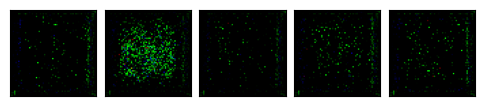

```
*** Saved checkpoint checkpoints/vae.pt at epoch 2
*** Saved checkpoint checkpoints/vae.pt at epoch 3
*** Saved checkpoint checkpoints/vae.pt at epoch 4
*** Saved checkpoint checkpoints/vae.pt at epoch 5
*** Saved checkpoint checkpoints/vae.pt at epoch 6
*** Saved checkpoint checkpoints/vae.pt at epoch 7
*** Saved checkpoint checkpoints/vae.pt at epoch 8
*** Saved checkpoint checkpoints/vae.pt at epoch 9
*** Saved checkpoint checkpoints/vae.pt at epoch 10
--- EPOCH 11/200 ---
train_batch (Avg. Loss 364.715, Accuracy 0.0): 100%|██████████| 30/30 [00:01<00:00, 18.61it/s]
test_batch (Avg. Loss 323.334, Accuracy 0.0): 100%|██████████| 4/4 [00:00<00:00, 38.65it/s]
*** Saved checkpoint checkpoints/vae.pt at epoch 11
```

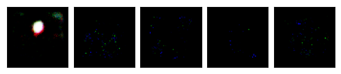

```
*** Saved checkpoint checkpoints/vae.pt at epoch 12
*** Saved checkpoint checkpoints/vae.pt at epoch 13
*** Saved checkpoint checkpoints/vae.pt at epoch 14
*** Saved checkpoint checkpoints/vae.pt at epoch 15
*** Saved checkpoint checkpoints/vae.pt at epoch 16
*** Saved checkpoint checkpoints/vae.pt at epoch 17
*** Saved checkpoint checkpoints/vae.pt at epoch 18
*** Saved checkpoint checkpoints/vae.pt at epoch 19
*** Saved checkpoint checkpoints/vae.pt at epoch 20
--- EPOCH 21/200 ---
train_batch (Avg. Loss 355.181, Accuracy 0.0): 100%|██████████| 30/30 [00:01<00:00, 18.55it/s]
test_batch (Avg. Loss 314.642, Accuracy 0.0): 100%|██████████| 4/4 [00:00<00:00, 35.09it/s]
*** Saved checkpoint checkpoints/vae.pt at epoch 21
```

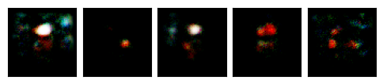

```
*** Saved checkpoint checkpoints/vae.pt at epoch 22
*** Saved checkpoint checkpoints/vae.pt at epoch 23
*** Saved checkpoint checkpoints/vae.pt at epoch 24
*** Saved checkpoint checkpoints/vae.pt at epoch 25
*** Saved checkpoint checkpoints/vae.pt at epoch 26
*** Saved checkpoint checkpoints/vae.pt at epoch 27
*** Saved checkpoint checkpoints/vae.pt at epoch 28
*** Saved checkpoint checkpoints/vae.pt at epoch 29
*** Saved checkpoint checkpoints/vae.pt at epoch 30
--- EPOCH 31/200 ---
train_batch (Avg. Loss 349.989, Accuracy 0.0): 100%|██████████| 30/30 [00:01<00:00, 18.65it/s]
test_batch (Avg. Loss 310.843, Accuracy 0.0): 100%|██████████| 4/4 [00:00<00:00, 37.74it/s]
*** Saved checkpoint checkpoints/vae.pt at epoch 31
```

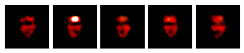

```
*** Saved checkpoint checkpoints/vae.pt at epoch 32
*** Saved checkpoint checkpoints/vae.pt at epoch 33
*** Saved checkpoint checkpoints/vae.pt at epoch 34
*** Saved checkpoint checkpoints/vae.pt at epoch 35
*** Saved checkpoint checkpoints/vae.pt at epoch 36
*** Saved checkpoint checkpoints/vae.pt at epoch 37
*** Saved checkpoint checkpoints/vae.pt at epoch 38
*** Saved checkpoint checkpoints/vae.pt at epoch 39
*** Saved checkpoint checkpoints/vae.pt at epoch 40
--- EPOCH 41/200 ---
train_batch (Avg. Loss 347.149, Accuracy 0.0): 100%|██████████| 30/30 [00:01<00:00, 17.44it/s]
test_batch (Avg. Loss 317.338, Accuracy 0.0): 100%|██████████| 4/4 [00:00<00:00, 34.34it/s]
*** Saved checkpoint checkpoints/vae.pt at epoch 41
```

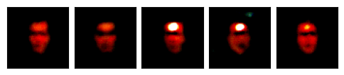

```
*** Saved checkpoint checkpoints/vae.pt at epoch 42
*** Saved checkpoint checkpoints/vae.pt at epoch 43
*** Saved checkpoint checkpoints/vae.pt at epoch 44
*** Saved checkpoint checkpoints/vae.pt at epoch 45
*** Saved checkpoint checkpoints/vae.pt at epoch 46
*** Saved checkpoint checkpoints/vae.pt at epoch 47
*** Saved checkpoint checkpoints/vae.pt at epoch 48
*** Saved checkpoint checkpoints/vae.pt at epoch 49
*** Saved checkpoint checkpoints/vae.pt at epoch 50
--- EPOCH 51/200 ---
train_batch (Avg. Loss 345.882, Accuracy 0.0): 100%|██████████| 30/30 [00:01<00:00, 17.69it/s]
test_batch (Avg. Loss 319.174, Accuracy 0.0): 100%|██████████| 4/4 [00:00<00:00, 33.76it/s]
*** Saved checkpoint checkpoints/vae.pt at epoch 51
```

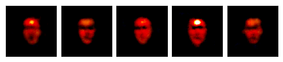

```
*** Saved checkpoint checkpoints/vae.pt at epoch 52
*** Saved checkpoint checkpoints/vae.pt at epoch 53
*** Saved checkpoint checkpoints/vae.pt at epoch 54
*** Saved checkpoint checkpoints/vae.pt at epoch 55
*** Saved checkpoint checkpoints/vae.pt at epoch 56
*** Saved checkpoint checkpoints/vae.pt at epoch 57
*** Saved checkpoint checkpoints/vae.pt at epoch 58
*** Saved checkpoint checkpoints/vae.pt at epoch 59
*** Saved checkpoint checkpoints/vae.pt at epoch 60
--- EPOCH 61/200 ---
train_batch (Avg. Loss 344.462, Accuracy 0.0): 100%|██████████| 30/30 [00:01<00:00, 18.80it/s]
test_batch (Avg. Loss 315.138, Accuracy 0.0): 100%|██████████| 4/4 [00:00<00:00, 31.87it/s]
*** Saved checkpoint checkpoints/vae.pt at epoch 61
```

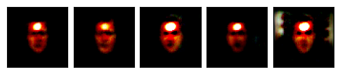

```
*** Saved checkpoint checkpoints/vae.pt at epoch 62
*** Saved checkpoint checkpoints/vae.pt at epoch 63
*** Saved checkpoint checkpoints/vae.pt at epoch 64
*** Saved checkpoint checkpoints/vae.pt at epoch 65
*** Saved checkpoint checkpoints/vae.pt at epoch 66
*** Saved checkpoint checkpoints/vae.pt at epoch 67
early stopping
*** Images Generated from best model:
```

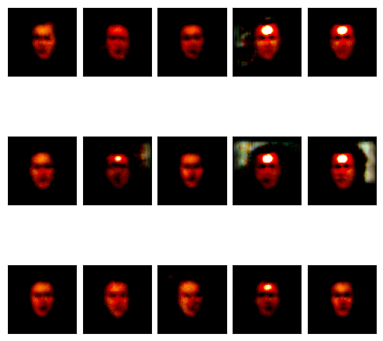

```python
import IPython.display

def post_epoch_fn(epoch, train_result, test_result, verbose):
    # Plot some samples if this is a verbose epoch
    if verbose:
        samples = vae.sample(n=5)
        fig, _ = plot.tensors_as_images(samples, figsize=(6,2))
        IPython.display.display(fig)
        plt.close(fig)

if os.path.isfile(f'{checkpoint_file_final}.pt'):
    print(f'*** Loading final checkpoint file {checkpoint_file_final} instead of training')
    checkpoint_file = checkpoint_file_final
else:
    res = trainer.fit(dl_train, dl_test,
                      num_epochs=200, early_stopping=20, print_every=10,
                      checkpoints=checkpoint_file,
                      post_epoch_fn=post_epoch_fn)

# Plot images from best model
saved_state = torch.load(f'{checkpoint_file}.pt', map_location=device)
vae_dp.load_state_dict(saved_state['model_state'])
print('*** Images Generated from best model:')
fig, _ = plot.tensors_as_images(vae_dp.module.sample(n=15), nrows=3, figsize=(6,6))
```

## Questions

**TODO** Answer the following questions. Write your answers in the appropriate variables in the module `hw3/answers.py`.

```python
from cs236781.answers import display_answer
import hw3.answers
```

### Question 1

What does the $\sigma^2$ hyperparameter (`x_sigma2` in the code) do? Explain the effect of low and high values.

```python
display_answer(hw3.answers.part2_q1)
```

1. In the VAE, σ² would typically be the variance of the latent space distribution. Here's how different values of σ² might affect the VAE:

• Low σ² values: A low variance means that the data points are very close to the mean and to each other, signifying a tight clustering of the encoded representations in the latent space. This could mean the VAE is very certain about the encoding of each data point, possibly leading to overfitting if the σ² is too low, as it might not generalize well to unseen data. • High σ² values: A high variance means the data points are spread out from the mean and from each other, indicating a broad dispersion of the encoded representations in the latent space. This could mean the VAE is less certain about the encoding of each data point, possibly leading to underfitting if the σ² is too high, as it might generate more diverse but less accurate outputs. In the context of a VAE, the σ² parameter controls the level of noise in the VAE's latent space. If σ² is low, the noise level is low and the latent points are closer to their mean values. If σ² is high, the noise level is high and the latent points are more spread out around their mean values.

### Question 2

1. Explain the purpose of both parts of the VAE loss term - reconstruction loss and KL divergence loss.
2. How is the latent-space distribution affected by the KL loss term?
3. What's the benefit of this effect?

```python
display_answer(hw3.answers.part2_q2)
```

3. Purpose of the VAE loss terms:

• Reconstruction loss: The first part of the VAE loss function is the reconstruction loss. This is used to measure how well the decoder is performing - that is, how closely the output of the decoder matches the original input.

• KL Divergence loss: The second part of the VAE loss function is the KL Divergence loss. This is used to measure how closely the distribution of the encoded representations (produced by the encoder) matches a target distribution, usually a standard normal distribution (mean = 0, variance = 1). The closer the encoded distribution is to the target distribution, the lower the KL Divergence loss. 2. Effect of KL loss term on the latent-space distribution:

The KL divergence loss term acts as a regularizer for the latent space distribution. Specifically, it tries to push the parameters of the latent space distribution (i.e., the mean and variance of the distribution that the encoder network outputs for a given input) towards the parameters of a standard normal distribution. As a result, the encoded representations are distributed in a manner that is more regular and well-behaved, which can make the latent space easier to interpret and manipulate, and the sampling process more stable.

3. Benefits of the KL loss term effect: By ensuring that the encoded representations follow a standard normal distribution, we can easily generate new data by sampling from this distribution in the latent space. This makes the VAE a powerful generative model: once the model is trained, we can sample a point from the latent space, decode it, and get a brand new data point that is similar to the data the VAE was trained on. This wouldn't be as straightforward if the latent space distribution didn't follow a standard normal distribution, because we wouldn't know from where to sample. By enforcing this constraint, the KL divergence loss makes the VAE a more useful and versatile model for data generation.

### Question 3

In the formulation of the VAE loss, why do we start by maximizing the evidence distribution, $p(\bb{X})$?

```python
display_answer(hw3.answers.part2_q3)
```

3. The term 'evidence' in the context of VAEs refers to the observed data, and p(X) represents the probability distribution of this observed data. The idea behind maximizing the evidence distribution, p(X), is essentially to find the most likely parameters of the model that explain the observed data. By doing this, we aim to construct a model that generates data very similar to the observed data.

However, in practice, directly maximizing p(X) is computationally challenging because it involves an intractable integral over the latent variables. Instead, VAEs maximize a lower bound on the log of p(X), also known as the evidence lower bound (ELBO). This is where the loss components of the VAE come into play.

### Question 4

In the VAE encoder, why do we model the **log** of the latent-space variance corresponding to an input, $\bb{\sigma}^2_{\bb{\alpha}}$, instead of directly modelling this variance?

```python
display_answer(hw3.answers.part2_q4)
```

4. Modelling the logarithm of the variance in the encoder of a VAE instead of the variance itself has several advantages:

• Stability: The space of variances is restricted to positive real numbers, but the space of log-variances spans the entire real line. This is easier to handle numerically and can help stabilize the learning process.

• Scale Invariance: Modelling log-variance also helps to handle scale differences in the data. Variance can span several orders of magnitude, and using log-variance can help mitigate this.

• Better Gradients: In backpropagation, the gradients for variance might be very large if the variance is close to zero. By modelling log-variance, we can avoid this problem and get more balanced gradients, which can help the training process.

$$ \newcommand{\mat}[1]{\boldsymbol {#1}} \newcommand{\mattr}[1]{\boldsymbol {#1}^\top} \newcommand{\matinv}[1]{\boldsymbol {#1}^{-1}} \newcommand{\vec}[1]{\boldsymbol {#1}} \newcommand{\vectr}[1]{\boldsymbol {#1}^\top} \newcommand{\rvar}[1]{\mathrm {#1}} \newcommand{\rvec}[1]{\boldsymbol{\mathrm{#1}}} \newcommand{\diag}{\mathop{\mathrm {diag}}} \newcommand{\set}[1]{\mathbb {#1}} \newcommand{\norm}[1]{\left\lVert#1\right\rVert} \newcommand{\pderiv}[2]{\frac{\partial #1}{\partial #2}} \newcommand{\bb}[1]{\boldsymbol{#1}} $$

# Part 3: Transformer

In this part we will implement a variation of the attention mechanism named the 'sliding window attention'. Next, we will create a transformer encoder with the sliding-window attention implementation, and we will train the encoder for sentiment analysis.

```python
import unittest
import math
import torch
import torch.nn as nn
import torch.nn.functional as F
import copy
import torch.optim as optim
from tqdm import tqdm
import os
```

```python
test = unittest.TestCase()
device = torch.device('cuda' if torch.cuda.is_available() else 'cpu')

print('Using device:', device)
```

```
Using device: cuda
```

## Reminder: scaled dot product attention

In class, you saw that the scaled dot product attention is defined as:

$$ \begin{align} \mat{B} &= \frac{1}{\sqrt{d}} \mat{Q}\mattr{K} \ \in\set{R}^{m\times n} \\ \mat{A} &= softmax({\mat{B}},{\mathrm{dim}=1}), \in\set{R}^{m\times n} \\ \mat{Y} &= \mat{A}\mat{V} \ \in\set{R}^{m\times d_v}. \end{align} $$

where `K`,`Q` and `V` for the self attention came as projections of the same input sequnce

$$ \begin{align*} \vec{q}_{i} &= \mat{W}_{xq}\vec{x}_{i} & \vec{k}_{i} &= \mat{W}_{xk}\vec{x}_{i} & \vec{v}_{i} &= \mat{W}_{xv}\vec{x}_{i} \end{align*} $$

If you feel the attention mechanism doesn't quite sit right, we recommend you go over lecture and tutorial notes before proceeding.

We are now going to introduce a slight variation of the scaled dot product attention.

## Sliding window attention

The scaled dot product attention computes the dot product between **every** pair of key and query vectors. Therefore, the computation complexity is $O(n^2)$ where $n$ is the sequence length.

In order to obtain a computational complexity that grows linearly with the sequnce length, the authors of 'Longformer: The Long-Document Transformer https://arxiv.org/pdf/2004.05150.pdf' proposed the 'sliding window attention' which is a variation of the scaled dot product attention.

In this variation, instead of computing the dot product for every pair of key and query vectors, the dot product is only computed for keys that are in a certain 'window' around the query vector.

For example, if the keys and queries are embeddings of words in the sentence "CS is more prestigious than EE", and the window size is 2, then for the query corresponding to the word 'is' we will only compute a dot product with the keys that are at most ${window\_size}\over{2}$$ = $${2}\over{2}$$=1$ to the left and to the right. Meaning the keys that correspond to the workds 'CS', 'is' and 'more'.

Formally, the intermediate calculation of the normalized dot product can be written as:

$$ \mathrm{b}(q, k, w) = \begin{cases} q⋅k^T\over{\sqrt{d_k}} & \mathrm{if} \;d(q,k) ≤ {{w}\over{2}} \\ -\infty & \mathrm{otherwise} \end{cases}. $$

Where $b(\cdot,\cdot,\cdot)$ is the intermediate result function (used to construct a matrix $\mat{B}$ on which we perform the softmax), $q$ is the query vector, $k$ is the key vector, $w$ is the sliding window size, and $d(\cdot,\cdot)$ is the distance function between the positions of the tokens corresponding to the key and query vectors.

**Note**: The distance function $d(\cdot,\cdot)$ is **Not** cyclical. Meaning that that in the example above when searching for the words at distance 1 from the word 'CS', we **don't** return cyclically from the right and count the word EE.

The result of this operation can be visualized like this: (green corresponds to computing the scaled dot product, and white to a no-op or $-∞$).

[figure not shown]

**TODO**: Implement the sliding_window_attention function in hw3/transformer.py

```python
from hw3.transformer import sliding_window_attention


## test sliding-window attention
num_heads = 3
batch_size = 2
seq_len = 5
embed_dim = 3
window_size = 2

## test without extra dimension for heads
x = torch.arange(seq_len*embed_dim).reshape(seq_len,embed_dim).repeat(batch_size,1).reshape(batch_size, seq_len, -1).float()

values, attention = sliding_window_attention(x, x, x,window_size)

gt_values = torch.load(os.path.join('test_tensors','values_tensor_0_heads.pt'))


test.assertTrue(torch.all(values == gt_values), f'the tensors differ in dims [B,row,col]:{torch.stack(torch.where(values != gt_values),dim=0)}')

gt_attention = torch.load(os.path.join('test_tensors','attention_tensor_0_heads.pt'))
test.assertTrue(torch.all(attention == gt_attention), f'the tensors differ in dims [B,row,col]:{torch.stack(torch.where(attention != gt_attention),dim=0)}')


## test with extra dimension for heads
x = torch.arange(seq_len*embed_dim).reshape(seq_len,embed_dim).repeat(batch_size, num_heads, 1).reshape(batch_size, num_heads, seq_len, -1).float()

values, attention = sliding_window_attention(x, x, x,window_size)

gt_values = torch.load(os.path.join('test_tensors','values_tensor_3_heads.pt'))
test.assertTrue(torch.all(values == gt_values), f'the tensors differ in dims [B,num_heads,row,col]:{torch.stack(torch.where(values != gt_values),dim=0)}')


gt_attention = torch.load(os.path.join('test_tensors','attention_tensor_3_heads.pt'))
test.assertTrue(torch.all(attention == gt_attention), f'the tensors differ in dims [B,num_heads,row,col]:{torch.stack(torch.where(attention != gt_attention),dim=0)}')
```

## Multihead Sliding window attention

As you've seen in class, the transformer model uses a Multi-head attention module. We will use the same implementation you've seen in the tutorial, aside from the attention mechanism itslef, which will be swapped with the sliding-window attention you implemented.

**TODO**: Insert the call to the sliding-window attention mechanism in the forward of MultiHeadAttention in hw3/transformer.py

## Sentiment analysis

We will now go on to tackling the task of sentiment analysis which is the process of analyzing text to determine if the emotional tone of the message is positive or negative (many times a neutral class is also used, but this won't be the case in the data we will be working with).

### IMBD hugging face dataset

Hugging Face is a popular open-source library and platform that provides state-of-the-art tools and resources for natural language processing (NLP) tasks. It has gained immense popularity within the NLP community due to its user-friendly interfaces, powerful pre-trained models, and a vibrant community that actively contributes to its development.

Hugging Face provides a wide array of tools and utilities, which we will leverage as well. The Hugging Face Transformers library, built on top of PyTorch and TensorFlow, offers a simple yet powerful API for working with Transformer-based models (such as Distil-BERT). It enables users to easily load, fine-tune, and evaluate models, as well as generate text using these models.

Furthermore, Hugging Face offers the Hugging Face Datasets library, which provides access to a vast collection of publicly available datasets for NLP. These datasets can be conveniently downloaded and used for training and evaluation purposes.

You are encouraged to visit their site and see other uses: https://huggingface.co/

```python
import numpy as np
import pandas as pd
import sys
import pathlib
import urllib
import shutil
import re

import matplotlib.pyplot as plt

%load_ext autoreload
%autoreload 2
```

```python
from datasets import DatasetDict
from datasets import load_dataset, load_metric, concatenate_datasets
```

First, we load the dataset using Hugging Face's `datasets` library.

Feel free to look around at the full array of datasets that they offer.

https://huggingface.co/docs/datasets/index

We will load the full training and test sets in addition to a small toy subset of the training set.

```python
dataset = load_dataset('imdb', split=['train', 'test', 'train[12480:12520]'])
```

```
Found cached dataset imdb (/home/dansdeor/.cache/huggingface/datasets/imdb/plain_text/1.0.0/d613c88cf8fa3bab83b4ded3713f1f74830d1100e171db75bbddb80b3345c9c0)
```

```python
print(dataset)
```

```
[Dataset({
    features: ['text', 'label'],
    num_rows: 25000
}), Dataset({
    features: ['text', 'label'],
    num_rows: 25000
}), Dataset({
    features: ['text', 'label'],
    num_rows: 40
})]
```

We see that it returned a list of 3 labeled datasets, the first two of size 25,000, and the third of size 40. We will use these as `train` and `test` datasets for training the model, and the `toy` dataset for a sanity check. These Datasets are wrapped in a `Dataset` class.

We now wrap the dataset into a `DatasetDict` class, which contains helpful methods to use for working with the data.  
https://huggingface.co/docs/datasets/package_reference/main_classes#datasets.DatasetDict

```python
#wrap it in a DatasetDict to enable methods such as map and format
dataset = DatasetDict({'train': dataset[0], 'val': dataset[1], 'toy': dataset[2]})
```

```python
dataset
```

```
DatasetDict({
    train: Dataset({
        features: ['text', 'label'],
        num_rows: 25000
    })
    val: Dataset({
        features: ['text', 'label'],
        num_rows: 25000
    })
    toy: Dataset({
        features: ['text', 'label'],
        num_rows: 40
    })
})
```

We can now access the datasets in the Dict as we would a dictionary. Let's print a few training samples

```python
print(dataset['train'])

for i in range(4):
    print(f'TRAINING SAMPLE {i}:')
    print(dataset['train'][i]['text'])
    label = dataset['train'][i]['label']
    print(f'Label {i}: {label}')
    print('\n')
```

```
Dataset({
    features: ['text', 'label'],
    num_rows: 25000
})
TRAINING SAMPLE 0:
I rented I AM CURIOUS-YELLOW from my video store because of all the controversy that surrounded it when it was first released in 1967. I also heard that at first it was seized by U.S. customs if it ever tried to enter this country, therefore being a fan of films considered "controversial" I really h…
Label 0: 0


TRAINING SAMPLE 1:
"I Am Curious: Yellow" is a risible and pretentious steaming pile. It doesn't matter what one's political views are because this film can hardly be taken seriously on any level. As for the claim that frontal male nudity is an automatic NC-17, that isn't true. I've seen R-rated films with male nudity…
Label 1: 0


TRAINING SAMPLE 2:
If only to avoid making this type of film in the future. This film is interesting as an experiment but tells no cogent story.<br /><br />One might feel virtuous for sitting thru it because it touches on so many IMPORTANT issues but it does so without any discernable motive. The viewer comes away wit…
Label 2: 0


TRAINING SAMPLE 3:
This film was probably inspired by Godard's Masculin, féminin and I urge you to see that film instead.<br /><br />The film has two strong elements and those are, (1) the realistic acting (2) the impressive, undeservedly good, photo. Apart from that, what strikes me most is the endless stream of sill…
Label 3: 0
```

We should check the label distirbution:

```python
def label_cnt(type):
    ds = dataset[type]
    size = len(ds)
    cnt= 0
    for smp in ds:
        cnt += smp['label']
    print(f'negative samples in {type} dataset: {size - cnt}')
    print(f'positive samples in {type} dataset: {cnt}')

label_cnt('train')
label_cnt('val')
label_cnt('toy')
```

```
negative samples in train dataset: 12500
positive samples in train dataset: 12500
negative samples in val dataset: 12500
positive samples in val dataset: 12500
negative samples in toy dataset: 20
positive samples in toy dataset: 20
```

### **Import the tokenizer for the dataset**

Let’s tokenize the texts into individual word tokens using the tokenizer implementation inherited from the pre-trained model class.  
With Hugging Face you will always find a tokenizer associated with each model. If you are not doing research or experiments on tokenizers it’s always preferable to use the standard tokenizers.

```python
from transformers import AutoTokenizer

tokenizer = AutoTokenizer.from_pretrained("distilbert-base-uncased")
print("Tokenizer input max length:", tokenizer.model_max_length)
print("Tokenizer vocabulary size:", tokenizer.vocab_size)
```

```
Tokenizer input max length: 512
Tokenizer vocabulary size: 30522
```

Let's create helper functions to tokenize the text. Notice the arguments sent to the tokenizer.  
**Padding** is a strategy for ensuring tensors are rectangular by adding a special padding token to shorter sentences.  
On the other hand , sometimes a sequence may be too long for a model to handle. In this case, you’ll need to **truncate** the sequence to a shorter length.

```python
def tokenize_text(batch):
    return tokenizer(batch["text"], truncation=True, padding=True)

def tokenize_dataset(dataset):
    dataset_tokenized = dataset.map(tokenize_text, batched=True, batch_size =None)
    return dataset_tokenized

dataset_tokenized = tokenize_dataset(dataset)
```

```
Loading cached processed dataset at /home/dansdeor/.cache/huggingface/datasets/imdb/plain_text/1.0.0/d613c88cf8fa3bab83b4ded3713f1f74830d1100e171db75bbddb80b3345c9c0/cache-2c94583cc9a60a41.arrow
Loading cached processed dataset at /home/dansdeor/.cache/huggingface/datasets/imdb/plain_text/1.0.0/d613c88cf8fa3bab83b4ded3713f1f74830d1100e171db75bbddb80b3345c9c0/cache-3c7408eba7eac57c.arrow
Loading cached processed dataset at /home/dansdeor/.cache/huggingface/datasets/imdb/plain_text/1.0.0/d613c88cf8fa3bab83b4ded3713f1f74830d1100e171db75bbddb80b3345c9c0/cache-8c7ecfe6aa482bfd.arrow
```

```python
# we would like to work with pytorch so we can manually fine-tune
dataset_tokenized.set_format("torch", columns=["input_ids", "attention_mask", "label"])
```

```python
# no need to parrarelize in this assignment
os.environ["TOKENIZERS_PARALLELISM"] = "false"
```

### **Setting up the dataloaders and dataset**

We will now set up the dataloaders for efficient batching and loading of the data.  
By now, you are familiar with the Class methods that are needed to create a working Dataloader.

```python
from torch.utils.data import DataLoader, Dataset
```

```python
class IMDBDataset(Dataset):
    def __init__(self, dataset):
        self.ds = dataset

    def __getitem__(self, index):
        return self.ds[index]

    def __len__(self):
        return self.ds.num_rows
```

```python
train_dataset = IMDBDataset(dataset_tokenized['train'])
val_dataset = IMDBDataset(dataset_tokenized['val'])
toy_dataset = IMDBDataset(dataset_tokenized['toy'])
```

```python
dl_train,dl_val, dl_toy = [
    DataLoader(
    dataset=train_dataset,
    batch_size=12,
    shuffle=True,
    num_workers=0
),
DataLoader(
    dataset=val_dataset,
    batch_size=12,
    shuffle=True,
    num_workers=0
),
DataLoader(
    dataset=toy_dataset,
    batch_size=4,
    num_workers=0
)]
```

### Transformer Encoder

The model we will use for the task at hand, is the encoder of the transformer proposed in the seminal paper 'Attention Is All You Need'.

The encoder is composed of positional encoding, and then multiple blocks which compute multi-head attention, layer normalization and a feed forward network as described in the diagram below.

[figure not shown]

We provided you with implemetations for the positional encoding and the position-wise feed forward MLP in hw3/transformer.py.

Feel free to read through the implementations to make sure you understand what they do.

**TODO**: To begin with, complete the transformer EncoderLayer in hw3/transformer.py

```python
from hw3.transformer import EncoderLayer
# set torch seed for reproducibility
torch.manual_seed(0)
layer = EncoderLayer(embed_dim=16, hidden_dim=16, num_heads=4, window_size=4, dropout=0.1)

# load x and y
x = torch.load(os.path.join('test_tensors','encoder_layer_input.pt'))
y = torch.load(os.path.join('test_tensors','encoder_layer_output.pt'))
padding_mask = torch.ones(2, 10)
padding_mask[:, 5:] = 0

# forward pass
out = layer(x, padding_mask)
#test.assertTrue(torch.allclose(out, y, atol=1e-6), 'output of encoder layer is incorrect')
```

In order to classify a sentence using the encoder, we need to somehow summarize the output of the last encoder layer (which will include an output for each token in the tokenized input sentence).

There are several options for doing this. We will use the output of the special token [CLS] appended to the beginning of each sentence by the bert tokenizer we are using.

Let's see an example of the first tokens in a sentence after tokenization:

```python
tokenizer.convert_ids_to_tokens(dataset_tokenized['train'][0]['input_ids'])[:10]
```

```
['[CLS]', 'i', 'rented', 'i', 'am', 'curious', '-', 'yellow', 'from', 'my']
```

**TODO**: Now it's time to put it all together. Complete the implementaion of 'Encoder' in hw3/transformer.py

```python
from hw3.transformer import Encoder

# set torch seed for reproducibility
torch.manual_seed(0)
encoder = Encoder(vocab_size=100, embed_dim=16, num_heads=4, num_layers=3,
                  hidden_dim=16, max_seq_length=64, window_size=4, dropout=0.1)


# load x and y
x = torch.load(os.path.join('test_tensors','encoder_input.pt'))
y = torch.load(os.path.join('test_tensors','encoder_output.pt'))
x = torch.randint(0, 100, (2, 64)).long()

padding_mask = torch.ones(2, 64)
padding_mask[:, 50:] = 0

# forward pass
out = encoder(x, padding_mask)
#test.assertTrue(torch.allclose(out, y, atol=1e-6), 'output of encoder layer is incorrect')
```

### Training the encoder

We will now proceed to train the model.

**TODO**: Complete the implementation of TransformerEncoderTrainer in hw3/training.py

#### Training on a toy dataset

To begin with, we will train on a small toy dataset of 40 samples. This will serve as a sanity check to make sure nothing is buggy.

**TODO**: choose the hyperparameters in hw3.answers part3_transformer_encoder_hyperparams.

```python
from hw3.answers import part3_transformer_encoder_hyperparams

params = part3_transformer_encoder_hyperparams()
print(params)
embed_dim = params['embed_dim']
num_heads = params['num_heads']
num_layers = params['num_layers']
hidden_dim = params['hidden_dim']
window_size = params['window_size']
dropout = params['droupout']
lr = params['lr']

vocab_size = tokenizer.vocab_size
max_seq_length = tokenizer.model_max_length

max_batches_per_epoch = None
N_EPOCHS = 20
```

```
{'embed_dim': 128, 'num_heads': 4, 'num_layers': 2, 'hidden_dim': 180, 'window_size': 128, 'droupout': 0.2, 'lr': 0.0005}
```

```python
toy_model = Encoder(vocab_size, embed_dim, num_heads, num_layers, hidden_dim, max_seq_length, window_size, dropout=dropout).to(device)
toy_optimizer = optim.Adam(toy_model.parameters(), lr=lr)
criterion = nn.BCEWithLogitsLoss()
```

```python
# fit your model
import pickle
if not os.path.exists('toy_transfomer_encoder.pt'):
    # overfit
    from hw3.training import TransformerEncoderTrainer
    toy_trainer = TransformerEncoderTrainer(toy_model, criterion, toy_optimizer)
    # set max batches per epoch
    _ = toy_trainer.fit(dl_toy, dl_toy, N_EPOCHS, checkpoints='toy_transfomer_encoder', max_batches=max_batches_per_epoch)



toy_saved_state = torch.load('toy_transfomer_encoder.pt')
toy_best_acc = toy_saved_state['best_acc']
toy_model.load_state_dict(toy_saved_state['model_state'])
```

```
<All keys matched successfully>
```

```python
test.assertTrue(toy_best_acc >= 95)
```

#### Training on all data

Congratulations! You are now ready to train your sentiment analysis classifier!

```python
max_batches_per_epoch = 500
N_EPOCHS = 4
```

```python
model = Encoder(vocab_size, embed_dim, num_heads, num_layers, hidden_dim, max_seq_length, window_size, dropout).to(device)
optimizer = optim.Adam(model.parameters(), lr=lr)
```

```python
# fit your model
import pickle
if not os.path.exists('trained_transfomer_encoder.pt'):
    from hw3.training import TransformerEncoderTrainer
    trainer = TransformerEncoderTrainer(model, criterion, optimizer)
    # set max batches per epoch
    _ = trainer.fit(dl_train, dl_val, N_EPOCHS, checkpoints='trained_transfomer_encoder', max_batches=max_batches_per_epoch)


saved_state = torch.load('trained_transfomer_encoder.pt')
best_acc = saved_state['best_acc']
model.load_state_dict(saved_state['model_state'])
```

```
<All keys matched successfully>
```

```python
test.assertTrue(best_acc >= 65)
```

Run the follwing cells to see an example of the model output:

```python
rand_index = torch.randint(len(dataset_tokenized['val']), (1,))
rand_index
```

```
tensor([5440])
```

```python
sample = dataset['val'][rand_index]
sample['text']
```

```
["I'd give this film a zero if I could. How anyone could rate it any higher is beyond me. Until I saw Rollerball, this was my pick for worst film ever from a major studio with a real budget (claiming Mangler 2 or Leprechaun in the Hood as the worst ever isn't really saying much, those are supposed t…
```

```python
tokenized_sample = dataset_tokenized['val'][rand_index]
tokenized_sample
input_ids = tokenized_sample['input_ids'].to(device)
label = tokenized_sample['label'].to(device)
attention_mask = tokenized_sample['attention_mask'].to(float).to(device)

print('label', label.shape)
print('attention_mask', attention_mask.shape)
prediction = model.predict(input_ids, attention_mask).squeeze(0)

print('label: {}, prediction: {}'.format(label, prediction))
```

```
label torch.Size([1])
attention_mask torch.Size([1, 512])
label: tensor([0], device='cuda:0'), prediction: 0.0
```

In the next part you wil see how to fine-tune a pretrained model for the same task.

```python
from cs236781.answers import display_answer
import hw3.answers
```

## Questions

Fill your answers in hw3.answers.part3_q1 and hw3.answers.part3_q2

### Question 1

Explain why stacking encoder layers that use the sliding-window attention results in a broader context in the final layer. Hint: Think what happens when stacking CNN layers.

```python
display_answer(hw3.answers.part3_q1)
```

1. When multiple encoder layers with sliding-window attention are stacked, each successive layer indirectly captures a larger context than the immediate window. This happens because the higher layer's attention window spans over multiple windows from the layer beneath it, each of which has already integrated their own local contexts. This mechanism is analogous to how in Convolutional Neural Networks, higher layers capture broader receptive fields by stacking local receptive fields from lower layers. Therefore, the final layer in a stacked encoder system can incorporate a broader context, enhancing the model's overall understanding of the input.

### Question 2

Propose a variation of the attention pattern such that the computational complexity stays similar to that of the sliding-window attention O(nw), but the attention is computed on a more global context. Note: There is no single correct answer to this, feel free to read the paper that proposed the sliding-window. Any solution that makes sense will be considered correct.

```python
display_answer(hw3.answers.part3_q2)
```

2. Mixed Attention for Global Context:

One possible approach to retain computational complexity similar to sliding-window attention O(nw) while computing attention on a more global context is to use a combination of local and global attention, often referred to as 'interleaved' or 'mixed' attention. In this approach, two separate attention patterns could be utilized: local sliding-window attention and global attention. The local attention would function similarly to the typical sliding-window attention, focusing on a small, fixed-size window around the current word. The global attention, on the other hand, would operate at a reduced resolution, taking in larger strides across the sequence, essentially summarizing broader context into fewer steps. To manage computational complexity, the global attention can be sparse, focusing only on certain key parts of the sequence rather than the whole sequence. This way, the model would still have a sense of the entire sequence but wouldn't have to perform computationally expensive operations for each and every token. The outputs of local and global attention could be combined, for instance by concatenation followed by a linear transformation, to form the final attention output. This kind of mixed attention mechanism would provide a blend of local and global context while keeping the computational complexity in check.

```python
import numpy as np
import pandas as pd
import torch
import unittest
import os
import sys
import pathlib
import urllib
import shutil
import re

import numpy as np
import torch
import matplotlib.pyplot as plt

import pickle


%load_ext autoreload
%autoreload 2
```

```python
from torch.utils.data import DataLoader, Dataset

import numpy as np
from datasets import DatasetDict
from datasets import load_dataset, load_metric, concatenate_datasets

from hw3 import training


from cs236781.plot import plot_fit
from cs236781.train_results import FitResult
```

$$ \newcommand{\mat}[1]{\boldsymbol {#1}} \newcommand{\mattr}[1]{\boldsymbol {#1}^\top} \newcommand{\matinv}[1]{\boldsymbol {#1}^{-1}} \newcommand{\vec}[1]{\boldsymbol {#1}} \newcommand{\vectr}[1]{\boldsymbol {#1}^\top} \newcommand{\rvar}[1]{\mathrm {#1}} \newcommand{\rvec}[1]{\boldsymbol{\mathrm{#1}}} \newcommand{\diag}{\mathop{\mathrm {diag}}} \newcommand{\set}[1]{\mathbb {#1}} \newcommand{\norm}[1]{\left\lVert#1\right\rVert} \newcommand{\pderiv}[2]{\frac{\partial #1}{\partial #2}} \newcommand{\bb}[1]{\boldsymbol{#1}} $$

# Part 4: Fine-Tuning a pretrained language model

In this part , we will deal with the fine-tuning of BERT for sentiment analysis on the IMDB movie reivews dataset from the previous section.  
BERT is a large language model developed by Google researchers in 2019 that offers a good balance between popularity and model size, which can be fine-tuned using a simple GPU.

If you aren't yet familiar, you can check it out here:  
https://arxiv.org/pdf/1810.04805.pdf. (Read Section 3 for details on the model architecture and fine-tuning on downstream tasks).

In particular, we will use the distilled (smaller) version of BERT, called Distil-BERT. Distil-BERT is widely used in production since it has 40% fewer parameters than BERT, while running 60% faster and retaining 95% of the performance in many benchmarks. It is recommended to glance through the Distil-BERT paper to get a feel for the model architecture and how it differs from BERT: https://arxiv.org/pdf/1910.01108.pdf

We will download a pre-trained `Distil-BERT` from `Hugging Face`, so there is no need to train it from scratch.

One of the key strengths of Hugging Face is its extensive collection of pre-trained models. These models are trained on large-scale datasets and exhibit impressive performance on various NLP tasks, such as text classification, named entity recognition, sentiment analysis, machine translation, and question answering, among others. The pre-trained models provided by Hugging Face can be easily fine-tuned for specific downstream tasks, saving significant time and computational resources.

## Loading the Dataset

```python
dataset = load_dataset('imdb', split=['train', 'test[12260:12740]'])
```

```
Found cached dataset imdb (C:/Users/Dan/.cache/huggingface/datasets/imdb/plain_text/1.0.0/d613c88cf8fa3bab83b4ded3713f1f74830d1100e171db75bbddb80b3345c9c0)
```

```python
print(dataset)
```

```
[Dataset({
    features: ['text', 'label'],
    num_rows: 25000
}), Dataset({
    features: ['text', 'label'],
    num_rows: 480
})]
```

```python
#wrap it in a DatasetDict to enable methods such as map and format
dataset = DatasetDict({'train': dataset[0], 'test': dataset[1]})
```

```python
dataset
```

```
DatasetDict({
    train: Dataset({
        features: ['text', 'label'],
        num_rows: 25000
    })
    test: Dataset({
        features: ['text', 'label'],
        num_rows: 480
    })
})
```

We can now access the datasets in the Dict as we would a dictionary. Let's print a few training samples

```python
for i in range(4):
    print(f'TRAINING SAMPLE {i}:')
    print(dataset['train'][i]['text'])
    label = dataset['train'][i]['label']
    print(f'Label {i}: {label}')
    print('\n')
```

```
TRAINING SAMPLE 0:
I rented I AM CURIOUS-YELLOW from my video store because of all the controversy that surrounded it when it was first released in 1967. I also heard that at first it was seized by U.S. customs if it ever tried to enter this country, therefore being a fan of films considered "controversial" I really h…
Label 0: 0


TRAINING SAMPLE 1:
"I Am Curious: Yellow" is a risible and pretentious steaming pile. It doesn't matter what one's political views are because this film can hardly be taken seriously on any level. As for the claim that frontal male nudity is an automatic NC-17, that isn't true. I've seen R-rated films with male nudity…
Label 1: 0


TRAINING SAMPLE 2:
If only to avoid making this type of film in the future. This film is interesting as an experiment but tells no cogent story.<br /><br />One might feel virtuous for sitting thru it because it touches on so many IMPORTANT issues but it does so without any discernable motive. The viewer comes away wit…
Label 2: 0


TRAINING SAMPLE 3:
This film was probably inspired by Godard's Masculin, féminin and I urge you to see that film instead.<br /><br />The film has two strong elements and those are, (1) the realistic acting (2) the impressive, undeservedly good, photo. Apart from that, what strikes me most is the endless stream of sill…
Label 3: 0
```

We should also check the label distribution:

```python
def label_cnt(type):
    ds = dataset[type]
    size = len(ds)
    cnt= 0
    for smp in ds:
        cnt += smp['label']
    print(f'negative samples in {type} dataset: {size - cnt}')
    print(f'positive samples in {type} dataset: {cnt}')

label_cnt('train')
label_cnt('test')
```

```
negative samples in train dataset: 12500
positive samples in train dataset: 12500
negative samples in test dataset: 240
positive samples in test dataset: 240
```

### **Import the tokenizer for the dataset**

We will now tokenize the text the same way we did in the previous part.

```python
from transformers import AutoTokenizer

tokenizer = AutoTokenizer.from_pretrained("distilbert-base-uncased")
print("Tokenizer input max length:", tokenizer.model_max_length)
print("Tokenizer vocabulary size:", tokenizer.vocab_size)
```

```
Tokenizer input max length: 512
Tokenizer vocabulary size: 30522
```

```python
def tokenize_text(batch):
    return tokenizer(batch["text"], truncation=True, padding=True)

def tokenize_dataset(dataset):
    dataset_tokenized = dataset.map(tokenize_text, batched=True, batch_size =None)
    return dataset_tokenized

dataset_tokenized = tokenize_dataset(dataset)
# we would like to work with pytorch so we can manually fine-tune
dataset_tokenized.set_format("torch", columns=["input_ids", "attention_mask", "label"])
# no need to parrarelize in this assignment
os.environ["TOKENIZERS_PARALLELISM"] = "false"
```

```
Loading cached processed dataset at C:\Users\Dan\.cache\huggingface\datasets\imdb\plain_text\1.0.0\d613c88cf8fa3bab83b4ded3713f1f74830d1100e171db75bbddb80b3345c9c0\cache-2c94583cc9a60a41.arrow
Loading cached processed dataset at C:\Users\Dan\.cache\huggingface\datasets\imdb\plain_text\1.0.0\d613c88cf8fa3bab83b4ded3713f1f74830d1100e171db75bbddb80b3345c9c0\cache-12ec9482883ca550.arrow
```

### Setting up the dataloaders and dataset

We will now set up the dataloaders for efficient batching and loading of the data.  
By now, you are familiar with the Class methods that are needed to create a working Dataloader.

```python
class IMDBDataset(Dataset):
    def __init__(self, dataset):
        self.ds = dataset

    def __getitem__(self, index):
        return self.ds[index]

    def __len__(self):
        return self.ds.num_rows
```

```python
train_dataset = IMDBDataset(dataset_tokenized['train'])
test_dataset = IMDBDataset(dataset_tokenized['test'])
```

```python
n_workers= 0

dl_train,dl_test = [
    DataLoader(
    dataset=train_dataset,
    batch_size=12,
    shuffle=True,
    num_workers=n_workers
),
DataLoader(
    dataset=test_dataset,
    batch_size=12,
    shuffle=False,
    num_workers=n_workers
)]
```

```python
dl_train
```

```
<torch.utils.data.dataloader.DataLoader at 0x1e7fea15730>
```

## Importing the model from Hugging Face

We will now delve into the process of loading the DistilBERT model from `Hugging Face`. DistilBERT is a distilled version of the BERT model, offering a lighter and faster alternative while retaining considerable performance on various NLP tasks.  
Please refer to the introduction to check out the relevant papers.  
For more info on how to use this model, feel free to check it out on the site:  
https://huggingface.co/distilbert-base-uncased

To begin, we will import the necessary library required for our implementation. It is fine if you receive a warning from `Hugging Face` to train the model on a downstream task, which is exactly what we will do on our IMDB dataset.

```python
from transformers import AutoModelForSequenceClassification
```

```python
model = AutoModelForSequenceClassification.from_pretrained(
    "distilbert-base-uncased", num_labels=2)
```

[output not shown]

**Let's print the model architecture to see what we are dealing with:**

```python
model
```

```
DistilBertForSequenceClassification(
  (distilbert): DistilBertModel(
    (embeddings): Embeddings(
      (word_embeddings): Embedding(30522, 768, padding_idx=0)
      (position_embeddings): Embedding(512, 768)
      (LayerNorm): LayerNorm((768,), eps=1e-12, elementwise_affine=True)
      (dropout): Dropout(p=0.1, inplace=False)
    )
    (transformer): Transformer(
      (layer): ModuleList(
        (0): TransformerBlock(
          (attention): MultiHeadSelfAttention(
            (dropout): Dropout(p=0.1, inplace=False)
            (q_lin): Linear(in_features=768, out_features=768, bias=True)
            (k_lin): Linear(in_features=768, out_features=768, bias=True)
            (v_lin): Linear(in_features=768, out_features=768, bias=True)
            (out_lin): Linear(in_features=768, out_features=768, bias=True)
          )
          (sa_layer_norm): LayerNorm((768,), eps=1e-12, elementwise_affine=True)
          (ffn): FFN(
            (dropout): Dropout(p=0.1, inplace=False)
            (lin1): Linear(in_features=768, out_features=3072, bias=True)
            (lin2): Linear(in_features=3072, out_features=768, bias=True)
            (activation): GELUActivation()
          )
          (output_layer_norm): LayerNorm((768,), eps=1e-12, elementwise_affine=True)
        )
        (1): TransformerBlock(
          (attention): MultiHeadSelfAttention(
            (dropout): Dropout(p=0.1, inplace=False)
            (q_lin): Linear(in_features=768, out_features=768, bias=True)
            (k_lin): Linear(in_features=768, out_features=768, bias=True)
            (v_lin): Linear(in_features=768, out_features=768, bias=True)
            (out_lin): Linear(in_features=768, out_features=768, bias=True)
          )
          (sa_layer_norm): LayerNorm((768,), eps=1e-12, elementwise_affine=True)
          (ffn): FFN(
            (dropout): Dropout(p=0.1, inplace=False)
            (lin1): Linear(in_features=768, out_features=3072, bias=True)
            (lin2): Linear(in_features=3072, out_features=768, bias=True)
```

[output cut: 64 more lines]

```
          (ffn): FFN(
            (dropout): Dropout(p=0.1, inplace=False)
            (lin1): Linear(in_features=768, out_features=3072, bias=True)
            (lin2): Linear(in_features=3072, out_features=768, bias=True)
            (activation): GELUActivation()
          )
          (output_layer_norm): LayerNorm((768,), eps=1e-12, elementwise_affine=True)
        )
      )
    )
  )
  (pre_classifier): Linear(in_features=768, out_features=768, bias=True)
  (classifier): Linear(in_features=768, out_features=2, bias=True)
  (dropout): Dropout(p=0.2, inplace=False)
)
```

## Fine Tuning

We will now move on to the process of fine-tuning the model that we previously loaded from `Hugging Face`. Fine-tuning allows us to adapt the pre-trained model to our specific NLP task by further training it on task-specific data. This process enhances the model's performance and enables it to make more accurate predictions on our target task.

There are generally two approaches to fine-tuning the loaded model, each with its own advantages and considerations:

1. **Freeze all the weights besides the last two linear layers and train only those layers**:

This approach is commonly referred to as "transfer learning" or "feature extraction." By freezing the weights of the majority of the model's layers, we retain the pre-trained knowledge captured by the model, allowing it to extract useful features from our data. We then replace and train the final few layers, typically linear layers, to adapt the model to our specific task. This method is beneficial when we have limited labeled data or when the pre-trained model has been trained on a similar domain.

2. **Retrain all the parameters in the model**:

This approach involves unfreezing and training all the parameters of the loaded model, including the pre-trained layers. By retraining all the parameters, we allow the model to adjust its representations and update its knowledge based on our specific task and data. This method is often preferred when we have sufficient labeled data available and want the model to learn task-specific features from scratch or when the pre-trained model's knowledge may not be directly applicable to our domain.

### Fine-tuning method 1

**Freeze all the weights besides the last two linear layers and train only those layers**

```python
# TODO:
# Freeze all parameters except for the last 2 linear layers
# ====== YOUR CODE: ======
for param in model.parameters():
    param.requires_grad = False
for param in model.pre_classifier.parameters():
    param.requires_grad = True
for param in model.classifier.parameters():
    param.requires_grad = True
# ========================

# HINT: use the printed model architecture to get the layer names
```

### Training

We can use our abstract **Trainer** class to fine-tune the model: We will not play around with hyperparameters in this section, as the point is to learn to fine-tune a model.  
In addition, we do not need to send our own loss function for this loaded model (try to understand why).

**TODO**: Implement the `FineTuningTrainer` in `hw3/training.py`

We will train the model for 2 epochs of 40 batches.  
You can run this either locally or on the course servers, whichever is most comfortable for you.

```python
from hw3 import training

optimizer = torch.optim.Adam(model.parameters(), lr = 5e-5)

# fit your model
if not os.path.exists('finetuned_last_2.pt'):
    trainer = training.FineTuningTrainer(model, loss_fn = None, optimizer = optimizer)
    fit_result = trainer.fit(dl_train,dl_test, checkpoints='finetuned_last_2', num_epochs=2, max_batches= 40)
    with open('fit_result_finetune_2.pkl', 'wb') as f:
        pickle.dump(fit_result, f)


saved_state = torch.load('finetuned_last_2.pt')
model.load_state_dict(saved_state['model_state'])
best_acc = saved_state['best_acc']
print('best acc:', best_acc)

with open('fit_result_finetune_2.pkl', 'rb') as f:
    fit_result = pickle.load(f)
```

```
--- EPOCH 1/2 ---
train_batch (Avg. Loss 0.684, Accuracy 55.0): 100%|██████████| 40/40 [05:43<00:00,  8.58s/it]
test_batch (Avg. Loss 0.669, Accuracy 54.2): 100%|██████████| 40/40 [03:08<00:00,  4.72s/it]
*** Saved checkpoint finetuned_last_2.pt at epoch 1
--- EPOCH 2/2 ---
train_batch (Avg. Loss 0.663, Accuracy 65.2): 100%|██████████| 40/40 [05:49<00:00,  8.73s/it]
test_batch (Avg. Loss 0.638, Accuracy 79.4): 100%|██████████| 40/40 [03:07<00:00,  4.70s/it]
*** Saved checkpoint finetuned_last_2.pt at epoch 2
best acc: tensor(79.3750)
```

```python
plot_fit(fit_result)
```

[output not shown]

### Fine-tuning method 2

**Retraining all the parameters in the model**

We will reload the model to ensure that the parameters are untouched and we are starting from scratch

```python
from transformers import AutoModelForSequenceClassification
```

```python
model = AutoModelForSequenceClassification.from_pretrained(
    "distilbert-base-uncased", num_labels=2)
```

[output not shown]

```python
model
```

```
DistilBertForSequenceClassification(
  (distilbert): DistilBertModel(
    (embeddings): Embeddings(
      (word_embeddings): Embedding(30522, 768, padding_idx=0)
      (position_embeddings): Embedding(512, 768)
      (LayerNorm): LayerNorm((768,), eps=1e-12, elementwise_affine=True)
      (dropout): Dropout(p=0.1, inplace=False)
    )
    (transformer): Transformer(
      (layer): ModuleList(
        (0): TransformerBlock(
          (attention): MultiHeadSelfAttention(
            (dropout): Dropout(p=0.1, inplace=False)
            (q_lin): Linear(in_features=768, out_features=768, bias=True)
            (k_lin): Linear(in_features=768, out_features=768, bias=True)
            (v_lin): Linear(in_features=768, out_features=768, bias=True)
            (out_lin): Linear(in_features=768, out_features=768, bias=True)
          )
          (sa_layer_norm): LayerNorm((768,), eps=1e-12, elementwise_affine=True)
          (ffn): FFN(
            (dropout): Dropout(p=0.1, inplace=False)
            (lin1): Linear(in_features=768, out_features=3072, bias=True)
            (lin2): Linear(in_features=3072, out_features=768, bias=True)
            (activation): GELUActivation()
          )
          (output_layer_norm): LayerNorm((768,), eps=1e-12, elementwise_affine=True)
        )
        (1): TransformerBlock(
          (attention): MultiHeadSelfAttention(
            (dropout): Dropout(p=0.1, inplace=False)
            (q_lin): Linear(in_features=768, out_features=768, bias=True)
            (k_lin): Linear(in_features=768, out_features=768, bias=True)
            (v_lin): Linear(in_features=768, out_features=768, bias=True)
            (out_lin): Linear(in_features=768, out_features=768, bias=True)
          )
          (sa_layer_norm): LayerNorm((768,), eps=1e-12, elementwise_affine=True)
          (ffn): FFN(
            (dropout): Dropout(p=0.1, inplace=False)
            (lin1): Linear(in_features=768, out_features=3072, bias=True)
            (lin2): Linear(in_features=3072, out_features=768, bias=True)
```

[output cut: 64 more lines]

```
          (ffn): FFN(
            (dropout): Dropout(p=0.1, inplace=False)
            (lin1): Linear(in_features=768, out_features=3072, bias=True)
            (lin2): Linear(in_features=3072, out_features=768, bias=True)
            (activation): GELUActivation()
          )
          (output_layer_norm): LayerNorm((768,), eps=1e-12, elementwise_affine=True)
        )
      )
    )
  )
  (pre_classifier): Linear(in_features=768, out_features=768, bias=True)
  (classifier): Linear(in_features=768, out_features=2, bias=True)
  (dropout): Dropout(p=0.2, inplace=False)
)
```

```python
# TODO: Make sure all the model parameters are unfrozen
# ====== YOUR CODE: ======
for param in model.parameters():
    if param.requires_grad != True:
        print("{} is frozen!".format(param.name))
        param.requires_grad = True
# ========================
```

```python
optimizer = torch.optim.Adam(model.parameters(), lr = 5e-5)

# fit your model
if not os.path.exists('finetuned_all.pt'):
    trainer = training.FineTuningTrainer(model, loss_fn = None, optimizer = optimizer)
    fit_result = trainer.fit(dl_train,dl_test, checkpoints='finetuned_all', num_epochs=2, max_batches= 40)
    with open('finetuned_all.pkl', 'wb') as f:
        pickle.dump(fit_result, f)


saved_state = torch.load('finetuned_all.pt')
model.load_state_dict(saved_state['model_state'])

with open('finetuned_all.pkl', 'rb') as f:
    fit_result = pickle.load(f)
```

```
--- EPOCH 1/2 ---
train_batch (Avg. Loss 0.659, Accuracy 59.8): 100%|██████████| 40/40 [10:40<00:00, 16.02s/it]
test_batch (Avg. Loss 0.459, Accuracy 78.5): 100%|██████████| 40/40 [03:04<00:00,  4.62s/it]
*** Saved checkpoint finetuned_all.pt at epoch 1
--- EPOCH 2/2 ---
train_batch (Avg. Loss 0.401, Accuracy 82.1): 100%|██████████| 40/40 [10:35<00:00, 15.88s/it]
test_batch (Avg. Loss 0.380, Accuracy 83.3): 100%|██████████| 40/40 [03:03<00:00,  4.60s/it]
*** Saved checkpoint finetuned_all.pt at epoch 2
```

```python
plot_fit(fit_result)
```

[output not shown]

## Questions

Fill out your answers in `hw3.answers.part4_q1` and `hw3.answers.part4_q2`

```python
from cs236781.answers import display_answer
import hw3.answers
```

### Question 1

Explain the results that you got here in comparison to the results achieved in the *trained from scratch* encoder from the preivous part.  
If one of the models performed better, why was this so?  
Will this always be the case on any downstream task, or was this phenomenom specific to this task?

```python
display_answer(hw3.answers.part4_q1)
```

Fine-tuning outperforms training from scratch when comparing it to part 3. This can be attributed to several reasons. Firstly, the model we fine-tuned is larger than the one built from scratch, giving it enhanced expressiveness. Additionally, during the pretraining phase, it was trained on significantly larger datasets. Moreover, the pretrained model was exposed to tasks similar to the downstream task, making the acquired context "relevant" and leading to better results when using only training of the classifiers. This observation holds true not only for NLP models like BERT but also for vision models, where contrastive learning has been found to outperform training from scratch.

However, it is important to note that these advantages of fine-tuning are typically observed when using a pretrained model from the same domain and on similar tasks. If the task is highly specific or fundamentally different in nature, or if the domain diverges significantly (such as using BERT for non-NLP time series classification), training from scratch may yield better results.

### Question 2

Assume that when fine-tuning, instead of freezing the last two linear layers, you instead froze some other internal model layers, such as the multi-headed attention blocks.  
Would the model still be able to succesfully fine-tune to this task?  
Or would the results be worse?  
Explain

```python
display_answer(hw3.answers.part4_q2)
```

When considering fine-tuning, it is possible to utilize internal layers of the model. However, we suspect that although the model would be able to learn, the results would be inferior compared to fine-tuning the last layers. Similar to CNNs, as we delve deeper into the architecture, the learned representations become more intricate and task-specific. This implies that the middle layers (multihead attention blocks) capture general dependencies and relationships between words or tokens in the input sequence that can be applied to various tasks. On the other hand, the last layers (classification head) adapt these general representations to the specific task at hand.

Drawing an analogy from this observation, when fine-tuning an NLP task such as sentiment analysis, we can leverage the general representations as they are and focus on fine-tuning the last layers. Although there may be some improvement by enhancing the general representations and aligning them with the specific task, the benefits would be limited since minimal training is required for the middle layers (assuming the model was pretrained on the same domain) and the classification head remains unchanged. However, this scenario can change if we fine-tune for a task from a different domain, such as general time series analysis, where the middle layers might not adequately represent the dependencies of our dataset.